# Project: Identify Customer Segments

In this project, you will apply unsupervised learning techniques to identify segments of the population that form the core customer base for a mail-order sales company in Germany. These segments can then be used to direct marketing campaigns towards audiences that will have the highest expected rate of returns. The data that you will use has been provided by our partners at Bertelsmann Arvato Analytics, and represents a real-life data science task.

This notebook will help you complete this task by providing a framework within which you will perform your analysis steps. In each step of the project, you will see some text describing the subtask that you will perform, followed by one or more code cells for you to complete your work. **Feel free to add additional code and markdown cells as you go along so that you can explore everything in precise chunks.** The code cells provided in the base template will outline only the major tasks, and will usually not be enough to cover all of the minor tasks that comprise it.

It should be noted that while there will be precise guidelines on how you should handle certain tasks in the project, there will also be places where an exact specification is not provided. **There will be times in the project where you will need to make and justify your own decisions on how to treat the data.** These are places where there may not be only one way to handle the data. In real-life tasks, there may be many valid ways to approach an analysis task. One of the most important things you can do is clearly document your approach so that other scientists can understand the decisions you've made.

At the end of most sections, there will be a Markdown cell labeled **Discussion**. In these cells, you will report your findings for the completed section, as well as document the decisions that you made in your approach to each subtask. **Your project will be evaluated not just on the code used to complete the tasks outlined, but also your communication about your observations and conclusions at each stage.**

```python
# import libraries here; add more as necessary
import numpy as np
import pandas as pd
import matplotlib.pyplot as plt
import seaborn as sns

# magic word for producing visualizations in notebook
%matplotlib inline
from sklearn.preprocessing import Imputer
from sklearn.preprocessing import StandardScaler
from sklearn.decomposition import PCA
from sklearn.cluster import KMeans
from sklearn.metrics import mean_squared_error
from sklearn.metrics import silhouette_samples, silhouette_score
from scipy.stats import ks_2samp
from sklearn.preprocessing import RobustScaler
```

### Step 0: Load the Data

There are four files associated with this project (not including this one):

Each row of the demographics files represents a single person, but also includes information outside of individuals, including information about their household, building, and neighborhood. You will use this information to cluster the general population into groups with similar demographic properties. Then, you will see how the people in the customers dataset fit into those created clusters. The hope here is that certain clusters are over-represented in the customers data, as compared to the general population; those over-represented clusters will be assumed to be part of the core userbase. This information can then be used for further applications, such as targeting for a marketing campaign.

To start off with, load in the demographics data for the general population into a pandas DataFrame, and do the same for the feature attributes summary. Note for all of the `.csv` data files in this project: they're semicolon (`;`) delimited, so you'll need an additional argument in your [`read_csv()`](https://pandas.pydata.org/pandas-docs/stable/generated/pandas.read_csv.html) call to read in the data properly. Also, considering the size of the main dataset, it may take some time for it to load completely.

Once the dataset is loaded, it's recommended that you take a little bit of time just browsing the general structure of the dataset and feature summary file. You'll be getting deep into the innards of the cleaning in the first major step of the project, so gaining some general familiarity can help you get your bearings.

```python
# Load in the general demographics data.
azdias = pd.read_csv('Udacity_AZDIAS_Subset.csv', sep=';')

# Load in the feature summary file.
feat_info = pd.read_csv('AZDIAS_Feature_Summary.csv', sep=';')
```

```python
# Check the structure of the data after it's loaded (e.g. print the number of
# rows and columns, print the first few rows).
azdias.shape
```

```
(891221, 85)
```

```python
azdias.head()
```

|  | AGER_TYP | ALTERSKATEGORIE_GROB | ANREDE_KZ | CJT_GESAMTTYP | FINANZ_MINIMALIST | FINANZ_SPARER | FINANZ_VORSORGER | FINANZ_ANLEGER | FINANZ_UNAUFFAELLIGER | FINANZ_HAUSBAUER | ... | PLZ8_ANTG1 | PLZ8_ANTG2 | PLZ8_ANTG3 | PLZ8_ANTG4 | PLZ8_BAUMAX | PLZ8_HHZ | PLZ8_GBZ | ARBEIT | ORTSGR_KLS9 | RELAT_AB |
| --- | --- | --- | --- | --- | --- | --- | --- | --- | --- | --- | --- | --- | --- | --- | --- | --- | --- | --- | --- | --- | --- |
| 0 | -1 | 2 | 1 | 2.0 | 3 | 4 | 3 | 5 | 5 | 3 | ... | NaN | NaN | NaN | NaN | NaN | NaN | NaN | NaN | NaN | NaN |
| 1 | -1 | 1 | 2 | 5.0 | 1 | 5 | 2 | 5 | 4 | 5 | ... | 2.0 | 3.0 | 2.0 | 1.0 | 1.0 | 5.0 | 4.0 | 3.0 | 5.0 | 4.0 |
| 2 | -1 | 3 | 2 | 3.0 | 1 | 4 | 1 | 2 | 3 | 5 | ... | 3.0 | 3.0 | 1.0 | 0.0 | 1.0 | 4.0 | 4.0 | 3.0 | 5.0 | 2.0 |
| 3 | 2 | 4 | 2 | 2.0 | 4 | 2 | 5 | 2 | 1 | 2 | ... | 2.0 | 2.0 | 2.0 | 0.0 | 1.0 | 3.0 | 4.0 | 2.0 | 3.0 | 3.0 |
| 4 | -1 | 3 | 1 | 5.0 | 4 | 3 | 4 | 1 | 3 | 2 | ... | 2.0 | 4.0 | 2.0 | 1.0 | 2.0 | 3.0 | 3.0 | 4.0 | 6.0 | 5.0 |

5 rows × 85 columns

```python
azdias.describe()
```

|  | AGER_TYP | ALTERSKATEGORIE_GROB | ANREDE_KZ | CJT_GESAMTTYP | FINANZ_MINIMALIST | FINANZ_SPARER | FINANZ_VORSORGER | FINANZ_ANLEGER | FINANZ_UNAUFFAELLIGER | FINANZ_HAUSBAUER | ... | PLZ8_ANTG1 | PLZ8_ANTG2 | PLZ8_ANTG3 | PLZ8_ANTG4 | PLZ8_BAUMAX | PLZ8_HHZ | PLZ8_GBZ | ARBEIT | ORTSGR_KLS9 | RELAT_AB |
| --- | --- | --- | --- | --- | --- | --- | --- | --- | --- | --- | --- | --- | --- | --- | --- | --- | --- | --- | --- | --- | --- |
| count | 891221.000000 | 891221.000000 | 891221.000000 | 886367.000000 | 891221.000000 | 891221.000000 | 891221.000000 | 891221.000000 | 891221.000000 | 891221.000000 | ... | 774706.000000 | 774706.000000 | 774706.000000 | 774706.000000 | 774706.000000 | 774706.000000 | 774706.000000 | 794005.000000 | 794005.000000 | 794005.00000 |
| mean | -0.358435 | 2.777398 | 1.522098 | 3.632838 | 3.074528 | 2.821039 | 3.401106 | 3.033328 | 2.874167 | 3.075121 | ... | 2.253330 | 2.801858 | 1.595426 | 0.699166 | 1.943913 | 3.612821 | 3.381087 | 3.167854 | 5.293002 | 3.07222 |
| std | 1.198724 | 1.068775 | 0.499512 | 1.595021 | 1.321055 | 1.464749 | 1.322134 | 1.529603 | 1.486731 | 1.353248 | ... | 0.972008 | 0.920309 | 0.986736 | 0.727137 | 1.459654 | 0.973967 | 1.111598 | 1.002376 | 2.303739 | 1.36298 |
| min | -1.000000 | 1.000000 | 1.000000 | 1.000000 | 1.000000 | 1.000000 | 1.000000 | 1.000000 | 1.000000 | 1.000000 | ... | 0.000000 | 0.000000 | 0.000000 | 0.000000 | 1.000000 | 1.000000 | 1.000000 | 1.000000 | 0.000000 | 1.00000 |
| 25% | -1.000000 | 2.000000 | 1.000000 | 2.000000 | 2.000000 | 1.000000 | 3.000000 | 2.000000 | 2.000000 | 2.000000 | ... | 1.000000 | 2.000000 | 1.000000 | 0.000000 | 1.000000 | 3.000000 | 3.000000 | 3.000000 | 4.000000 | 2.00000 |
| 50% | -1.000000 | 3.000000 | 2.000000 | 4.000000 | 3.000000 | 3.000000 | 3.000000 | 3.000000 | 3.000000 | 3.000000 | ... | 2.000000 | 3.000000 | 2.000000 | 1.000000 | 1.000000 | 4.000000 | 3.000000 | 3.000000 | 5.000000 | 3.00000 |
| 75% | -1.000000 | 4.000000 | 2.000000 | 5.000000 | 4.000000 | 4.000000 | 5.000000 | 5.000000 | 4.000000 | 4.000000 | ... | 3.000000 | 3.000000 | 2.000000 | 1.000000 | 3.000000 | 4.000000 | 4.000000 | 4.000000 | 7.000000 | 4.00000 |
| max | 3.000000 | 9.000000 | 2.000000 | 6.000000 | 5.000000 | 5.000000 | 5.000000 | 5.000000 | 5.000000 | 5.000000 | ... | 4.000000 | 4.000000 | 3.000000 | 2.000000 | 5.000000 | 5.000000 | 5.000000 | 9.000000 | 9.000000 | 9.00000 |

8 rows × 81 columns

```python
feat_info.shape
```

```
(85, 4)
```

```python
feat_info. head()
```

|  | attribute | information_level | type | missing_or_unknown |
| --- | --- | --- | --- | --- |
| 0 | AGER_TYP | person | categorical | [-1,0] |
| 1 | ALTERSKATEGORIE_GROB | person | ordinal | [-1,0,9] |
| 2 | ANREDE_KZ | person | categorical | [-1,0] |
| 3 | CJT_GESAMTTYP | person | categorical | [0] |
| 4 | FINANZ_MINIMALIST | person | ordinal | [-1] |

```python
np.unique(feat_info['missing_or_unknown'], return_counts= True)
```

```
(array(['[-1,0,9]', '[-1,0]', '[-1,9]', '[-1,XX]', '[-1,X]', '[-1]', '[0]',
        '[XX]', '[]'], dtype=object),
 array([ 1, 16, 17,  1,  1, 26, 12,  1, 10]))
```

> **Tip**: Add additional cells to keep everything in reasonably-sized chunks! Keyboard shortcut `esc --> a` (press escape to enter command mode, then press the 'A' key) adds a new cell before the active cell, and `esc --> b` adds a new cell after the active cell. If you need to convert an active cell to a markdown cell, use `esc --> m` and to convert to a code cell, use `esc --> y`.

## Step 1: Preprocessing

### Step 1.1: Assess Missing Data

The feature summary file contains a summary of properties for each demographics data column. You will use this file to help you make cleaning decisions during this stage of the project. First of all, you should assess the demographics data in terms of missing data. Pay attention to the following points as you perform your analysis, and take notes on what you observe. Make sure that you fill in the **Discussion** cell with your findings and decisions at the end of each step that has one!

#### Step 1.1.1: Convert Missing Value Codes to NaNs

The fourth column of the feature attributes summary (loaded in above as `feat_info`) documents the codes from the data dictionary that indicate missing or unknown data. While the file encodes this as a list (e.g. `[-1,0]`), this will get read in as a string object. You'll need to do a little bit of parsing to make use of it to identify and clean the data. Convert data that matches a 'missing' or 'unknown' value code into a numpy NaN value. You might want to see how much data takes on a 'missing' or 'unknown' code, and how much data is naturally missing, as a point of interest.

**As one more reminder, you are encouraged to add additional cells to break up your analysis into manageable chunks.**

### Naturally Missing data

```python
null_values=azdias.isnull().sum(axis=0)
null_values
```

```
AGER_TYP                      0
ALTERSKATEGORIE_GROB          0
ANREDE_KZ                     0
CJT_GESAMTTYP              4854
FINANZ_MINIMALIST             0
FINANZ_SPARER                 0
FINANZ_VORSORGER              0
FINANZ_ANLEGER                0
FINANZ_UNAUFFAELLIGER         0
FINANZ_HAUSBAUER              0
FINANZTYP                     0
GEBURTSJAHR                   0
GFK_URLAUBERTYP            4854
GREEN_AVANTGARDE              0
HEALTH_TYP                    0
LP_LEBENSPHASE_FEIN        4854
LP_LEBENSPHASE_GROB        4854
LP_FAMILIE_FEIN            4854
LP_FAMILIE_GROB            4854
LP_STATUS_FEIN             4854
LP_STATUS_GROB             4854
NATIONALITAET_KZ              0
PRAEGENDE_JUGENDJAHRE         0
RETOURTYP_BK_S             4854
SEMIO_SOZ                     0
SEMIO_FAM                     0
SEMIO_REL                     0
SEMIO_MAT                     0
SEMIO_VERT                    0
SEMIO_LUST                    0
                          ...
OST_WEST_KZ               93148
WOHNLAGE                  93148
CAMEO_DEUG_2015           98979
CAMEO_DEU_2015            98979
CAMEO_INTL_2015           98979
KBA05_ANTG1              133324
KBA05_ANTG2              133324
KBA05_ANTG3              133324
KBA05_ANTG4              133324
KBA05_BAUMAX             133324
KBA05_GBZ                133324
BALLRAUM                  93740
EWDICHTE                  93740
INNENSTADT                93740
GEBAEUDETYP_RASTER        93155
KKK                      121196
MOBI_REGIO               133324
ONLINE_AFFINITAET          4854
REGIOTYP                 121196
KBA13_ANZAHL_PKW         105800
PLZ8_ANTG1               116515
PLZ8_ANTG2               116515
PLZ8_ANTG3               116515
PLZ8_ANTG4               116515
PLZ8_BAUMAX              116515
PLZ8_HHZ                 116515
PLZ8_GBZ                 116515
ARBEIT                    97216
ORTSGR_KLS9               97216
RELAT_AB                  97216
Length: 85, dtype: int64
```

```python
nan_columns=null_values[null_values>0].sort_values(ascending=False)
natural_missing_columns = nan_columns.to_frame()
```

I have created 2 new columns to analyse the features. Percentage of missing values WRT to entire data gives the percentage of naturally missing data in the entire dataset while Percentage of missing values WRT to missing data gives the percentage of missing data for the particular column in the total missing dataset.

```python
natural_missing_columns = natural_missing_columns.rename(columns = {0 : 'Number of missing values'})
natural_missing_columns['Percentage of missing values WRT to entire data'] = (natural_missing_columns['Number of missing values'] /azdias.shape[0] ) * 100
natural_missing_columns['Percentage of missing values WRT to missing data'] = (natural_missing_columns['Number of missing values'] / natural_missing_columns['Number of missing values'].sum()) * 100
natural_missing_columns
```

|  | Number of missing values | Percentage of missing values WRT to entire data | Percentage of missing values WRT to missing data |
| --- | --- | --- | --- |
| KK_KUNDENTYP | 584612 | 65.596749 | 11.938561 |
| KBA05_ANTG3 | 133324 | 14.959701 | 2.722655 |
| KBA05_ANTG2 | 133324 | 14.959701 | 2.722655 |
| KBA05_ANTG4 | 133324 | 14.959701 | 2.722655 |
| KBA05_BAUMAX | 133324 | 14.959701 | 2.722655 |
| KBA05_GBZ | 133324 | 14.959701 | 2.722655 |
| KBA05_ANTG1 | 133324 | 14.959701 | 2.722655 |
| MOBI_REGIO | 133324 | 14.959701 | 2.722655 |
| KKK | 121196 | 13.598872 | 2.474985 |
| REGIOTYP | 121196 | 13.598872 | 2.474985 |
| PLZ8_ANTG1 | 116515 | 13.073637 | 2.379393 |
| PLZ8_ANTG2 | 116515 | 13.073637 | 2.379393 |
| PLZ8_ANTG3 | 116515 | 13.073637 | 2.379393 |
| PLZ8_ANTG4 | 116515 | 13.073637 | 2.379393 |
| PLZ8_BAUMAX | 116515 | 13.073637 | 2.379393 |
| PLZ8_HHZ | 116515 | 13.073637 | 2.379393 |
| PLZ8_GBZ | 116515 | 13.073637 | 2.379393 |
| W_KEIT_KIND_HH | 107602 | 12.073549 | 2.197377 |
| KBA13_ANZAHL_PKW | 105800 | 11.871354 | 2.160578 |
| CAMEO_DEUG_2015 | 98979 | 11.106000 | 2.021284 |
| CAMEO_INTL_2015 | 98979 | 11.106000 | 2.021284 |
| CAMEO_DEU_2015 | 98979 | 11.106000 | 2.021284 |
| ORTSGR_KLS9 | 97216 | 10.908181 | 1.985281 |
| RELAT_AB | 97216 | 10.908181 | 1.985281 |
| ARBEIT | 97216 | 10.908181 | 1.985281 |
| ANZ_HH_TITEL | 97008 | 10.884842 | 1.981033 |
| EWDICHTE | 93740 | 10.518154 | 1.914297 |
| BALLRAUM | 93740 | 10.518154 | 1.914297 |
| INNENSTADT | 93740 | 10.518154 | 1.914297 |
| GEBAEUDETYP_RASTER | 93155 | 10.452514 | 1.902350 |
| WOHNLAGE | 93148 | 10.451729 | 1.902207 |
| OST_WEST_KZ | 93148 | 10.451729 | 1.902207 |
| MIN_GEBAEUDEJAHR | 93148 | 10.451729 | 1.902207 |
| GEBAEUDETYP | 93148 | 10.451729 | 1.902207 |
| ANZ_HAUSHALTE_AKTIV | 93148 | 10.451729 | 1.902207 |
| KONSUMNAEHE | 73969 | 8.299737 | 1.510546 |
| TITEL_KZ | 73499 | 8.247000 | 1.500948 |
| WOHNDAUER_2008 | 73499 | 8.247000 | 1.500948 |
| SOHO_KZ | 73499 | 8.247000 | 1.500948 |
| ANZ_TITEL | 73499 | 8.247000 | 1.500948 |
| ANZ_PERSONEN | 73499 | 8.247000 | 1.500948 |
| ALTER_HH | 73499 | 8.247000 | 1.500948 |
| HH_EINKOMMEN_SCORE | 18348 | 2.058749 | 0.374691 |
| ONLINE_AFFINITAET | 4854 | 0.544646 | 0.099125 |
| RETOURTYP_BK_S | 4854 | 0.544646 | 0.099125 |
| LP_STATUS_GROB | 4854 | 0.544646 | 0.099125 |
| LP_STATUS_FEIN | 4854 | 0.544646 | 0.099125 |
| LP_FAMILIE_GROB | 4854 | 0.544646 | 0.099125 |
| LP_FAMILIE_FEIN | 4854 | 0.544646 | 0.099125 |
| LP_LEBENSPHASE_GROB | 4854 | 0.544646 | 0.099125 |
| LP_LEBENSPHASE_FEIN | 4854 | 0.544646 | 0.099125 |
| GFK_URLAUBERTYP | 4854 | 0.544646 | 0.099125 |
| CJT_GESAMTTYP | 4854 | 0.544646 | 0.099125 |

#### Discussion : Access Naturally missing data in columns

Column 'KK_KUNDENTYP' has about 65.5% of data missing naturally and 11% of the total missing data in the dataset. There are 7 columns in the dataset 'KBA05_ANTG3', 'KBA05_ANTG2', 'KBA05_ANTG4', 'KBA05_BAUMAX', 'KBA05_GBZ', 'KBA05_ANTG1', 'MOBI_REGIO' which have around 15 % of the data missing on the corpus of entire data and 2.7% on the corpus of missing data.

### Convert values in demographic data based on missing or unknown code in features data

```python
# # Identify missing or unknown data values and convert them to NaNs.
# attribute = []
# for i in range (0, len(feat_info)):
#     list_value = feat_info.iloc[i]['missing_or_unknown']
#     if '-1' in list_value or '0' in list_value:
#         attribute.append(feat_info.iloc[i]['attribute'])
```

```python
# print (len(attribute))
```

```python
# for i in attribute:
#     value_series = azdias[i]
#     value_series = value_series.replace(-1,np.nan)
#     value_series = value_series.replace(0,np.nan)
#     azdias[i] = value_series
```

```python
# turn missing_or_unknown to list
feat_info['missing_or_unknown'] = feat_info['missing_or_unknown'].apply(lambda x: x[1:-1].split(','))
```

```python
# Identify missing or unknown data values and convert them to NaNs.
for attrib, missing_values in zip(feat_info['attribute'], feat_info['missing_or_unknown']):
    if missing_values[0] != '':
        for value in missing_values:
            if value.isnumeric() or value.lstrip('-').isnumeric():
                value = int(value)
            azdias.loc[azdias[attrib] == value, attrib] = np.nan
```

#### Step 1.1.2: Assess Missing Data in Each Column

How much missing data is present in each column? There are a few columns that are outliers in terms of the proportion of values that are missing. You will want to use matplotlib's [`hist()`](https://matplotlib.org/api/_as_gen/matplotlib.pyplot.hist.html) function to visualize the distribution of missing value counts to find these columns. Identify and document these columns. While some of these columns might have justifications for keeping or re-encoding the data, for this project you should just remove them from the dataframe. (Feel free to make remarks about these outlier columns in the discussion, however!)

For the remaining features, are there any patterns in which columns have, or share, missing data?

```python
# Perform an assessment of how much missing data there is in each column of the
# dataset.
null_values_including_missing_code  =azdias.isnull().sum(axis = 0)
```

```python
# Investigate patterns in the amount of missing data in each column.

nan_columns_with_missing_code=null_values_including_missing_code[null_values_including_missing_code>0].sort_values(ascending=False)
missing_code_appended = nan_columns_with_missing_code.to_frame()
missing_code_appended = missing_code_appended.rename(columns = {0 : 'Number of missing values'})
missing_code_appended['Percentage of missing values WRT entire data'] = (missing_code_appended['Number of missing values'] / azdias.shape[0]) * 100
missing_code_appended['Percentage of missing values WRT missing data'] = (missing_code_appended['Number of missing values'] / missing_code_appended['Number of missing values'].sum()) * 100
missing_code_appended
```

|  | Number of missing values | Percentage of missing values WRT entire data | Percentage of missing values WRT missing data |
| --- | --- | --- | --- |
| TITEL_KZ | 889061 | 99.757636 | 10.617011 |
| AGER_TYP | 685843 | 76.955435 | 8.190218 |
| KK_KUNDENTYP | 584612 | 65.596749 | 6.981335 |
| KBA05_BAUMAX | 476524 | 53.468668 | 5.690567 |
| GEBURTSJAHR | 392318 | 44.020282 | 4.684993 |
| ALTER_HH | 310267 | 34.813699 | 3.705154 |
| REGIOTYP | 158064 | 17.735668 | 1.887573 |
| KKK | 158064 | 17.735668 | 1.887573 |
| W_KEIT_KIND_HH | 147988 | 16.605084 | 1.767247 |
| KBA05_ANTG4 | 133324 | 14.959701 | 1.592132 |
| KBA05_GBZ | 133324 | 14.959701 | 1.592132 |
| MOBI_REGIO | 133324 | 14.959701 | 1.592132 |
| KBA05_ANTG1 | 133324 | 14.959701 | 1.592132 |
| KBA05_ANTG2 | 133324 | 14.959701 | 1.592132 |
| KBA05_ANTG3 | 133324 | 14.959701 | 1.592132 |
| PLZ8_GBZ | 116515 | 13.073637 | 1.391402 |
| PLZ8_HHZ | 116515 | 13.073637 | 1.391402 |
| PLZ8_BAUMAX | 116515 | 13.073637 | 1.391402 |
| PLZ8_ANTG4 | 116515 | 13.073637 | 1.391402 |
| PLZ8_ANTG1 | 116515 | 13.073637 | 1.391402 |
| PLZ8_ANTG3 | 116515 | 13.073637 | 1.391402 |
| PLZ8_ANTG2 | 116515 | 13.073637 | 1.391402 |
| SHOPPER_TYP | 111196 | 12.476816 | 1.327883 |
| VERS_TYP | 111196 | 12.476816 | 1.327883 |
| HEALTH_TYP | 111196 | 12.476816 | 1.327883 |
| NATIONALITAET_KZ | 108315 | 12.153551 | 1.293479 |
| PRAEGENDE_JUGENDJAHRE | 108164 | 12.136608 | 1.291676 |
| KBA13_ANZAHL_PKW | 105800 | 11.871354 | 1.263445 |
| ANZ_HAUSHALTE_AKTIV | 99611 | 11.176913 | 1.189537 |
| CAMEO_INTL_2015 | 99352 | 11.147852 | 1.186444 |
| ... | ... | ... | ... |
| CAMEO_DEUG_2015 | 99352 | 11.147852 | 1.186444 |
| LP_LEBENSPHASE_FEIN | 97632 | 10.954859 | 1.165904 |
| RELAT_AB | 97375 | 10.926022 | 1.162835 |
| ARBEIT | 97375 | 10.926022 | 1.162835 |
| ORTSGR_KLS9 | 97274 | 10.914689 | 1.161629 |
| ANZ_HH_TITEL | 97008 | 10.884842 | 1.158453 |
| LP_LEBENSPHASE_GROB | 94572 | 10.611509 | 1.129362 |
| INNENSTADT | 93740 | 10.518154 | 1.119427 |
| BALLRAUM | 93740 | 10.518154 | 1.119427 |
| EWDICHTE | 93740 | 10.518154 | 1.119427 |
| GEBAEUDETYP_RASTER | 93155 | 10.452514 | 1.112441 |
| MIN_GEBAEUDEJAHR | 93148 | 10.451729 | 1.112357 |
| OST_WEST_KZ | 93148 | 10.451729 | 1.112357 |
| WOHNLAGE | 93148 | 10.451729 | 1.112357 |
| GEBAEUDETYP | 93148 | 10.451729 | 1.112357 |
| LP_FAMILIE_FEIN | 77792 | 8.728699 | 0.928978 |
| LP_FAMILIE_GROB | 77792 | 8.728699 | 0.928978 |
| KONSUMNAEHE | 73969 | 8.299737 | 0.883325 |
| WOHNDAUER_2008 | 73499 | 8.247000 | 0.877712 |
| ANZ_TITEL | 73499 | 8.247000 | 0.877712 |
| SOHO_KZ | 73499 | 8.247000 | 0.877712 |
| ANZ_PERSONEN | 73499 | 8.247000 | 0.877712 |
| HH_EINKOMMEN_SCORE | 18348 | 2.058749 | 0.219109 |
| LP_STATUS_GROB | 4854 | 0.544646 | 0.057966 |
| LP_STATUS_FEIN | 4854 | 0.544646 | 0.057966 |
| RETOURTYP_BK_S | 4854 | 0.544646 | 0.057966 |
| ONLINE_AFFINITAET | 4854 | 0.544646 | 0.057966 |
| GFK_URLAUBERTYP | 4854 | 0.544646 | 0.057966 |
| CJT_GESAMTTYP | 4854 | 0.544646 | 0.057966 |
| ALTERSKATEGORIE_GROB | 2881 | 0.323264 | 0.034404 |

61 rows × 3 columns

After the missing and unknown codes are converted into Nan's, there is a change in the columns having high missing data compared to the columns having missing data naturally.

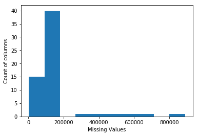

```python
plt.hist(missing_code_appended['Number of missing values'])
plt.xlabel("Missing Values")
plt.ylabel("Count of columns")
plt.show()
```

```python
#Find columns with no missing values
cols_missing_data = missing_code_appended.index.tolist()
total_cols = azdias.columns.tolist()
no_missing_columns = np.setdiff1d(total_cols,cols_missing_data)
no_missing_columns
```

```
array(['ANREDE_KZ', 'FINANZTYP', 'FINANZ_ANLEGER', 'FINANZ_HAUSBAUER',
       'FINANZ_MINIMALIST', 'FINANZ_SPARER', 'FINANZ_UNAUFFAELLIGER',
       'FINANZ_VORSORGER', 'GREEN_AVANTGARDE', 'SEMIO_DOM', 'SEMIO_ERL',
       'SEMIO_FAM', 'SEMIO_KAEM', 'SEMIO_KRIT', 'SEMIO_KULT', 'SEMIO_LUST',
       'SEMIO_MAT', 'SEMIO_PFLICHT', 'SEMIO_RAT', 'SEMIO_REL', 'SEMIO_SOZ',
       'SEMIO_TRADV', 'SEMIO_VERT', 'ZABEOTYP'],
      dtype='<U21')
```

```python
# Remove the outlier columns from the dataset. (You'll perform other data
# engineering tasks such as re-encoding and imputation later.)

azdias = azdias.drop( labels = ['TITEL_KZ', 'AGER_TYP', 'KK_KUNDENTYP', 'KBA05_BAUMAX', 'GEBURTSJAHR', 'ALTER_HH'], axis = 1)
```

```python
azdias.shape
```

```
(891221, 79)
```

#### Step 1.1.3: Assess Missing Data in Each Row

Now, you'll perform a similar assessment for the rows of the dataset. How much data is missing in each row? As with the columns, you should see some groups of points that have a very different numbers of missing values. Divide the data into two subsets: one for data points that are above some threshold for missing values, and a second subset for points below that threshold.

In order to know what to do with the outlier rows, we should see if the distribution of data values on columns that are not missing data (or are missing very little data) are similar or different between the two groups. Select at least five of these columns and compare the distribution of values.

- You can use seaborn's [`countplot()`](https://seaborn.pydata.org/generated/seaborn.countplot.html) function to create a bar chart of code frequencies and matplotlib's [`subplot()`](https://matplotlib.org/api/_as_gen/matplotlib.pyplot.subplot.html) function to put bar charts for the two subplots side by side.
- To reduce repeated code, you might want to write a function that can perform this comparison, taking as one of its arguments a column to be compared.

Depending on what you observe in your comparison, this will have implications on how you approach your conclusions later in the analysis. If the distributions of non-missing features look similar between the data with many missing values and the data with few or no missing values, then we could argue that simply dropping those points from the analysis won't present a major issue. On the other hand, if the data with many missing values looks very different from the data with few or no missing values, then we should make a note on those data as special. We'll revisit these data later on. **Either way, you should continue your analysis for now using just the subset of the data with few or no missing values.**

```python
# How much data is missing in each row of the dataset?

rowise_null_values_including_missing_code  =azdias.isnull().sum(axis = 1)
```

```python
rowise_nan_columns_with_missing_code=rowise_null_values_including_missing_code[rowise_null_values_including_missing_code>7].sort_values(ascending=False)
rowise_missing_code_appended = rowise_nan_columns_with_missing_code.to_frame()
rowise_missing_code_appended = rowise_missing_code_appended.rename(columns = {0 : 'Number of missing values'})
rowise_missing_code_appended['Percentage of missing values WRT entire data'] = (rowise_missing_code_appended['Number of missing values'] / azdias.shape[1]) * 100
rowise_missing_code_appended['Percentage of missing values WRT missing data'] = (rowise_missing_code_appended['Number of missing values'] / rowise_missing_code_appended['Number of missing values'].sum()) * 100
rowise_missing_code_appended
```

|  | Number of missing values | Percentage of missing values WRT entire data | Percentage of missing values WRT missing data |
| --- | --- | --- | --- |
| 643174 | 49 | 62.025316 | 0.001072 |
| 732775 | 49 | 62.025316 | 0.001072 |
| 472919 | 48 | 60.759494 | 0.001051 |
| 261886 | 47 | 59.493671 | 0.001029 |
| 691984 | 47 | 59.493671 | 0.001029 |
| 280953 | 47 | 59.493671 | 0.001029 |
| 692019 | 47 | 59.493671 | 0.001029 |
| 692018 | 47 | 59.493671 | 0.001029 |
| 692010 | 47 | 59.493671 | 0.001029 |
| 692001 | 47 | 59.493671 | 0.001029 |
| 691993 | 47 | 59.493671 | 0.001029 |
| 691987 | 47 | 59.493671 | 0.001029 |
| 691986 | 47 | 59.493671 | 0.001029 |
| 691983 | 47 | 59.493671 | 0.001029 |
| 692024 | 47 | 59.493671 | 0.001029 |
| 455217 | 47 | 59.493671 | 0.001029 |
| 281026 | 47 | 59.493671 | 0.001029 |
| 455215 | 47 | 59.493671 | 0.001029 |
| 281051 | 47 | 59.493671 | 0.001029 |
| 281053 | 47 | 59.493671 | 0.001029 |
| 281060 | 47 | 59.493671 | 0.001029 |
| 281062 | 47 | 59.493671 | 0.001029 |
| 455211 | 47 | 59.493671 | 0.001029 |
| 280949 | 47 | 59.493671 | 0.001029 |
| 280940 | 47 | 59.493671 | 0.001029 |
| 280942 | 47 | 59.493671 | 0.001029 |
| 455208 | 47 | 59.493671 | 0.001029 |
| 280815 | 47 | 59.493671 | 0.001029 |
| 280819 | 47 | 59.493671 | 0.001029 |
| 280827 | 47 | 59.493671 | 0.001029 |
| ... | ... | ... | ... |
| 782910 | 8 | 10.126582 | 0.000175 |
| 139898 | 8 | 10.126582 | 0.000175 |
| 139873 | 8 | 10.126582 | 0.000175 |
| 640715 | 8 | 10.126582 | 0.000175 |
| 783175 | 8 | 10.126582 | 0.000175 |
| 139563 | 8 | 10.126582 | 0.000175 |
| 640493 | 8 | 10.126582 | 0.000175 |
| 640508 | 8 | 10.126582 | 0.000175 |
| 343191 | 8 | 10.126582 | 0.000175 |
| 139575 | 8 | 10.126582 | 0.000175 |
| 343165 | 8 | 10.126582 | 0.000175 |
| 139593 | 8 | 10.126582 | 0.000175 |
| 640534 | 8 | 10.126582 | 0.000175 |
| 783220 | 8 | 10.126582 | 0.000175 |
| 640540 | 8 | 10.126582 | 0.000175 |
| 640548 | 8 | 10.126582 | 0.000175 |
| 343113 | 8 | 10.126582 | 0.000175 |
| 640683 | 8 | 10.126582 | 0.000175 |
| 783142 | 8 | 10.126582 | 0.000175 |
| 139714 | 8 | 10.126582 | 0.000175 |
| 783090 | 8 | 10.126582 | 0.000175 |
| 783075 | 8 | 10.126582 | 0.000175 |
| 343064 | 8 | 10.126582 | 0.000175 |
| 640605 | 8 | 10.126582 | 0.000175 |
| 139802 | 8 | 10.126582 | 0.000175 |
| 783007 | 8 | 10.126582 | 0.000175 |
| 343038 | 8 | 10.126582 | 0.000175 |
| 139820 | 8 | 10.126582 | 0.000175 |
| 139837 | 8 | 10.126582 | 0.000175 |
| 618330 | 8 | 10.126582 | 0.000175 |

144112 rows × 3 columns

```python
# Write code to divide the data into two subsets based on the number of missing
# values in each row.
azdias_few_missing_values=azdias[azdias.isnull().sum(axis = 1)<=20]
azdias_few_missing_values
```

|  | ALTERSKATEGORIE_GROB | ANREDE_KZ | CJT_GESAMTTYP | FINANZ_MINIMALIST | FINANZ_SPARER | FINANZ_VORSORGER | FINANZ_ANLEGER | FINANZ_UNAUFFAELLIGER | FINANZ_HAUSBAUER | FINANZTYP | ... | PLZ8_ANTG1 | PLZ8_ANTG2 | PLZ8_ANTG3 | PLZ8_ANTG4 | PLZ8_BAUMAX | PLZ8_HHZ | PLZ8_GBZ | ARBEIT | ORTSGR_KLS9 | RELAT_AB |
| --- | --- | --- | --- | --- | --- | --- | --- | --- | --- | --- | --- | --- | --- | --- | --- | --- | --- | --- | --- | --- | --- |
| 1 | 1.0 | 2.0 | 5.0 | 1.0 | 5.0 | 2.0 | 5.0 | 4.0 | 5.0 | 1.0 | ... | 2.0 | 3.0 | 2.0 | 1.0 | 1.0 | 5.0 | 4.0 | 3.0 | 5.0 | 4.0 |
| 2 | 3.0 | 2.0 | 3.0 | 1.0 | 4.0 | 1.0 | 2.0 | 3.0 | 5.0 | 1.0 | ... | 3.0 | 3.0 | 1.0 | 0.0 | 1.0 | 4.0 | 4.0 | 3.0 | 5.0 | 2.0 |
| 3 | 4.0 | 2.0 | 2.0 | 4.0 | 2.0 | 5.0 | 2.0 | 1.0 | 2.0 | 6.0 | ... | 2.0 | 2.0 | 2.0 | 0.0 | 1.0 | 3.0 | 4.0 | 2.0 | 3.0 | 3.0 |
| 4 | 3.0 | 1.0 | 5.0 | 4.0 | 3.0 | 4.0 | 1.0 | 3.0 | 2.0 | 5.0 | ... | 2.0 | 4.0 | 2.0 | 1.0 | 2.0 | 3.0 | 3.0 | 4.0 | 6.0 | 5.0 |
| 5 | 1.0 | 2.0 | 2.0 | 3.0 | 1.0 | 5.0 | 2.0 | 2.0 | 5.0 | 2.0 | ... | 2.0 | 3.0 | 1.0 | 1.0 | 1.0 | 5.0 | 5.0 | 2.0 | 3.0 | 3.0 |
| 6 | 2.0 | 2.0 | 5.0 | 1.0 | 5.0 | 1.0 | 5.0 | 4.0 | 3.0 | 4.0 | ... | 3.0 | 3.0 | 1.0 | 0.0 | 1.0 | 5.0 | 5.0 | 4.0 | 6.0 | 3.0 |
| 7 | 1.0 | 1.0 | 3.0 | 3.0 | 3.0 | 4.0 | 1.0 | 3.0 | 2.0 | 5.0 | ... | 3.0 | 3.0 | 1.0 | 0.0 | 1.0 | 4.0 | 4.0 | 2.0 | 5.0 | 2.0 |
| 8 | 3.0 | 1.0 | 3.0 | 4.0 | 4.0 | 2.0 | 4.0 | 2.0 | 2.0 | 6.0 | ... | 2.0 | 3.0 | 2.0 | 1.0 | 1.0 | 3.0 | 3.0 | 2.0 | 4.0 | 3.0 |
| 9 | 3.0 | 2.0 | 4.0 | 2.0 | 4.0 | 2.0 | 3.0 | 5.0 | 4.0 | 1.0 | ... | 2.0 | 3.0 | 2.0 | 1.0 | 1.0 | 3.0 | 3.0 | 2.0 | 3.0 | 1.0 |
| 10 | 3.0 | 2.0 | 1.0 | 2.0 | 2.0 | 5.0 | 3.0 | 1.0 | 5.0 | 6.0 | ... | 2.0 | 4.0 | 2.0 | 0.0 | 2.0 | 3.0 | 3.0 | 4.0 | 6.0 | 5.0 |
| 12 | 3.0 | 1.0 | 6.0 | 5.0 | 3.0 | 4.0 | 2.0 | 4.0 | 1.0 | 3.0 | ... | 3.0 | 3.0 | 1.0 | 0.0 | 1.0 | 5.0 | 5.0 | 3.0 | 6.0 | 4.0 |
| 13 | 1.0 | 2.0 | 5.0 | 1.0 | 4.0 | 3.0 | 5.0 | 5.0 | 2.0 | 1.0 | ... | 2.0 | 1.0 | 1.0 | 1.0 | 1.0 | 3.0 | 3.0 | 3.0 | 6.0 | 4.0 |
| 15 | 4.0 | 2.0 | 4.0 | 4.0 | 1.0 | 5.0 | 1.0 | 1.0 | 4.0 | 2.0 | ... | NaN | NaN | NaN | NaN | NaN | NaN | NaN | 4.0 | 8.0 | 5.0 |
| 16 | 1.0 | 2.0 | 1.0 | 4.0 | 3.0 | 1.0 | 4.0 | 5.0 | 1.0 | 3.0 | ... | 3.0 | 3.0 | 1.0 | 0.0 | 1.0 | 3.0 | 4.0 | 1.0 | 2.0 | 1.0 |
| 18 | 2.0 | 2.0 | 6.0 | 2.0 | 4.0 | 1.0 | 5.0 | 4.0 | 1.0 | 1.0 | ... | 2.0 | 3.0 | 2.0 | 1.0 | 1.0 | 3.0 | 3.0 | 3.0 | 4.0 | 3.0 |
| 19 | 3.0 | 1.0 | 3.0 | 5.0 | 2.0 | 3.0 | 1.0 | 3.0 | 1.0 | 5.0 | ... | 2.0 | 4.0 | 2.0 | 1.0 | 2.0 | 5.0 | 4.0 | 4.0 | 6.0 | 3.0 |
| 20 | 2.0 | 2.0 | 4.0 | 4.0 | 3.0 | 1.0 | 4.0 | 5.0 | 1.0 | 3.0 | ... | NaN | NaN | NaN | NaN | NaN | NaN | NaN | 3.0 | 4.0 | 1.0 |
| 21 | 2.0 | 1.0 | 3.0 | 3.0 | 4.0 | 1.0 | 2.0 | 5.0 | 1.0 | 3.0 | ... | 1.0 | 4.0 | 3.0 | 2.0 | 4.0 | 4.0 | 3.0 | 5.0 | 7.0 | 5.0 |
| 22 | 1.0 | 1.0 | 4.0 | 1.0 | 5.0 | 3.0 | 5.0 | 5.0 | 5.0 | 1.0 | ... | 2.0 | 4.0 | 2.0 | 1.0 | 2.0 | 4.0 | 3.0 | 4.0 | 5.0 | 5.0 |
| 23 | 3.0 | 1.0 | 3.0 | 5.0 | 3.0 | 3.0 | 2.0 | 2.0 | 1.0 | 6.0 | ... | NaN | NaN | NaN | NaN | NaN | NaN | NaN | 3.0 | 6.0 | 2.0 |
| 25 | 1.0 | 1.0 | 3.0 | 3.0 | 5.0 | 3.0 | 5.0 | 4.0 | 3.0 | 4.0 | ... | 2.0 | 2.0 | 0.0 | 0.0 | 1.0 | 4.0 | 5.0 | 3.0 | 2.0 | 5.0 |
| 26 | 3.0 | 1.0 | 3.0 | 5.0 | 2.0 | 4.0 | 2.0 | 3.0 | 1.0 | 3.0 | ... | NaN | NaN | NaN | NaN | NaN | NaN | NaN | 4.0 | 3.0 | 5.0 |
| 27 | 3.0 | 1.0 | 4.0 | 3.0 | 3.0 | 4.0 | 1.0 | 2.0 | 2.0 | 5.0 | ... | 2.0 | 3.0 | 3.0 | 2.0 | 4.0 | 5.0 | 3.0 | 4.0 | 7.0 | 5.0 |
| 28 | 3.0 | 1.0 | 2.0 | 3.0 | 2.0 | 4.0 | 3.0 | 3.0 | 2.0 | 3.0 | ... | 3.0 | 3.0 | 1.0 | 0.0 | 1.0 | 5.0 | 5.0 | 3.0 | 4.0 | 1.0 |
| 29 | 4.0 | 2.0 | 1.0 | 5.0 | 1.0 | 5.0 | 2.0 | 1.0 | 3.0 | 6.0 | ... | 3.0 | 2.0 | 2.0 | 0.0 | 1.0 | 3.0 | 4.0 | 2.0 | 4.0 | 3.0 |
| 31 | 2.0 | 2.0 | 6.0 | 1.0 | 5.0 | 2.0 | 3.0 | 5.0 | 4.0 | 1.0 | ... | 1.0 | 3.0 | 3.0 | 2.0 | 5.0 | 4.0 | 2.0 | 4.0 | 8.0 | 5.0 |
| 32 | 1.0 | 1.0 | 4.0 | 5.0 | 4.0 | 2.0 | 3.0 | 4.0 | 1.0 | 3.0 | ... | 2.0 | 3.0 | 1.0 | 0.0 | 1.0 | 3.0 | 4.0 | 4.0 | 3.0 | 5.0 |
| 33 | 2.0 | 2.0 | 4.0 | 2.0 | 2.0 | 4.0 | 1.0 | 3.0 | 4.0 | 5.0 | ... | 1.0 | 3.0 | 2.0 | 1.0 | 5.0 | 5.0 | 3.0 | 3.0 | 8.0 | 5.0 |
| 34 | 1.0 | 2.0 | 2.0 | 4.0 | 1.0 | 5.0 | 1.0 | 2.0 | 3.0 | 2.0 | ... | 2.0 | 3.0 | 2.0 | 1.0 | 1.0 | 3.0 | 3.0 | 4.0 | 7.0 | 5.0 |
| 36 | 3.0 | 2.0 | 2.0 | 2.0 | 3.0 | 4.0 | 3.0 | 2.0 | 3.0 | 6.0 | ... | 2.0 | 3.0 | 2.0 | 1.0 | 1.0 | 3.0 | 3.0 | 4.0 | 9.0 | 4.0 |
| ... | ... | ... | ... | ... | ... | ... | ... | ... | ... | ... | ... | ... | ... | ... | ... | ... | ... | ... | ... | ... | ... |
| 891191 | 4.0 | 2.0 | 1.0 | 4.0 | 1.0 | 5.0 | 1.0 | 1.0 | 4.0 | 2.0 | ... | 3.0 | 3.0 | 1.0 | 0.0 | 1.0 | 4.0 | 5.0 | 1.0 | 3.0 | 1.0 |
| 891192 | 1.0 | 2.0 | 3.0 | 1.0 | 5.0 | 2.0 | 5.0 | 3.0 | 5.0 | 1.0 | ... | 4.0 | 2.0 | 1.0 | 0.0 | 1.0 | 3.0 | 3.0 | 3.0 | 5.0 | 1.0 |
| 891193 | 4.0 | 1.0 | 3.0 | 4.0 | 1.0 | 5.0 | 1.0 | 2.0 | 5.0 | 5.0 | ... | 2.0 | 4.0 | 1.0 | 0.0 | 2.0 | 2.0 | 2.0 | 4.0 | 6.0 | 4.0 |
| 891194 | 3.0 | 1.0 | 4.0 | 4.0 | 3.0 | 4.0 | 2.0 | 3.0 | 1.0 | 3.0 | ... | 3.0 | 2.0 | 2.0 | 0.0 | 1.0 | 4.0 | 4.0 | 4.0 | 8.0 | 5.0 |
| 891195 | 4.0 | 2.0 | 6.0 | 3.0 | 1.0 | 5.0 | 1.0 | 1.0 | 5.0 | 2.0 | ... | 2.0 | 3.0 | 2.0 | 1.0 | 1.0 | 4.0 | 3.0 | 4.0 | 7.0 | 5.0 |
| 891196 | 2.0 | 2.0 | 6.0 | 1.0 | 5.0 | 2.0 | 5.0 | 4.0 | 3.0 | 1.0 | ... | 2.0 | 3.0 | 2.0 | 1.0 | 1.0 | 3.0 | 3.0 | 3.0 | 4.0 | 5.0 |
| 891197 | 3.0 | 2.0 | 1.0 | 3.0 | 2.0 | 4.0 | 1.0 | 3.0 | 3.0 | 5.0 | ... | 2.0 | 3.0 | 2.0 | 1.0 | 1.0 | 4.0 | 4.0 | 3.0 | 9.0 | 5.0 |
| 891198 | 3.0 | 1.0 | 5.0 | 2.0 | 5.0 | 3.0 | 4.0 | 5.0 | 3.0 | 1.0 | ... | 4.0 | 2.0 | 1.0 | 0.0 | 1.0 | 4.0 | 5.0 | 3.0 | 9.0 | 5.0 |
| 891199 | 2.0 | 1.0 | 3.0 | 2.0 | 5.0 | 2.0 | 3.0 | 3.0 | 4.0 | 1.0 | ... | 1.0 | 4.0 | 3.0 | 2.0 | 5.0 | 5.0 | 3.0 | 3.0 | 7.0 | 3.0 |
| 891200 | 1.0 | 2.0 | 3.0 | 1.0 | 5.0 | 3.0 | 5.0 | 5.0 | 5.0 | 1.0 | ... | 1.0 | 4.0 | 2.0 | 1.0 | 2.0 | 3.0 | 3.0 | 4.0 | 6.0 | 5.0 |
| 891201 | 3.0 | 1.0 | 3.0 | 4.0 | 2.0 | 3.0 | 2.0 | 2.0 | 3.0 | 6.0 | ... | 1.0 | 4.0 | 3.0 | 1.0 | 3.0 | 4.0 | 3.0 | 3.0 | 7.0 | 5.0 |
| 891202 | 2.0 | 2.0 | 5.0 | 1.0 | 4.0 | 1.0 | 2.0 | 5.0 | 4.0 | 1.0 | ... | 1.0 | 4.0 | 3.0 | 2.0 | 5.0 | 4.0 | 2.0 | 4.0 | 8.0 | 5.0 |
| 891203 | 4.0 | 2.0 | 1.0 | 4.0 | 1.0 | 5.0 | 1.0 | 3.0 | 4.0 | 5.0 | ... | 2.0 | 3.0 | 2.0 | 1.0 | 1.0 | 3.0 | 3.0 | 4.0 | 8.0 | 5.0 |
| 891204 | 3.0 | 1.0 | 5.0 | 4.0 | 3.0 | 4.0 | 4.0 | 2.0 | 1.0 | 6.0 | ... | 2.0 | 3.0 | 1.0 | 0.0 | 1.0 | 3.0 | 4.0 | 4.0 | 7.0 | 3.0 |
| 891205 | 4.0 | 1.0 | 2.0 | 4.0 | 2.0 | 4.0 | 3.0 | 3.0 | 4.0 | 2.0 | ... | 1.0 | 4.0 | 3.0 | 1.0 | 3.0 | 3.0 | 2.0 | 3.0 | 7.0 | 5.0 |
| 891206 | 1.0 | 2.0 | 4.0 | 3.0 | 4.0 | 2.0 | 4.0 | 4.0 | 2.0 | 4.0 | ... | 3.0 | 2.0 | 1.0 | 0.0 | 1.0 | 4.0 | 5.0 | 3.0 | 4.0 | 3.0 |
| 891207 | 3.0 | 2.0 | 1.0 | 5.0 | 1.0 | 5.0 | 1.0 | 2.0 | 4.0 | 2.0 | ... | 2.0 | 3.0 | 2.0 | 2.0 | 4.0 | 4.0 | 2.0 | 1.0 | 5.0 | 1.0 |
| 891208 | 4.0 | 1.0 | 2.0 | 5.0 | 2.0 | 4.0 | 2.0 | 3.0 | 1.0 | 6.0 | ... | 3.0 | 2.0 | 0.0 | 0.0 | 1.0 | 3.0 | 3.0 | 4.0 | 2.0 | 5.0 |
| 891209 | 1.0 | 2.0 | 5.0 | 1.0 | 4.0 | 2.0 | 3.0 | 4.0 | 4.0 | 1.0 | ... | 1.0 | 4.0 | 2.0 | 1.0 | 5.0 | 5.0 | 4.0 | 4.0 | 5.0 | 5.0 |
| 891210 | 3.0 | 1.0 | 5.0 | 3.0 | 3.0 | 4.0 | 2.0 | 2.0 | 2.0 | 6.0 | ... | 2.0 | 3.0 | 2.0 | 1.0 | 1.0 | 3.0 | 3.0 | 3.0 | 9.0 | 5.0 |
| 891211 | 3.0 | 1.0 | 2.0 | 3.0 | 2.0 | 4.0 | 3.0 | 3.0 | 2.0 | 2.0 | ... | 1.0 | 4.0 | 2.0 | 0.0 | 2.0 | 3.0 | 2.0 | 3.0 | 5.0 | 5.0 |
| 891212 | 4.0 | 1.0 | 1.0 | 3.0 | 1.0 | 5.0 | 1.0 | 1.0 | 5.0 | 5.0 | ... | 1.0 | 3.0 | 3.0 | 2.0 | 5.0 | 4.0 | 1.0 | 3.0 | 9.0 | 5.0 |
| 891213 | 4.0 | 2.0 | 5.0 | 3.0 | 3.0 | 3.0 | 5.0 | 3.0 | 2.0 | 6.0 | ... | 2.0 | 4.0 | 2.0 | 1.0 | 2.0 | 5.0 | 5.0 | 3.0 | 4.0 | 4.0 |
| 891214 | 1.0 | 2.0 | 4.0 | 1.0 | 5.0 | 2.0 | 3.0 | 3.0 | 4.0 | 1.0 | ... | 1.0 | 4.0 | 3.0 | 2.0 | 5.0 | 5.0 | 2.0 | 3.0 | 7.0 | 3.0 |
| 891215 | 2.0 | 2.0 | 6.0 | 1.0 | 5.0 | 2.0 | 4.0 | 5.0 | 4.0 | 1.0 | ... | 2.0 | 4.0 | 2.0 | 1.0 | 2.0 | 4.0 | 4.0 | 2.0 | 5.0 | 2.0 |
| 891216 | 3.0 | 2.0 | 5.0 | 1.0 | 4.0 | 2.0 | 5.0 | 4.0 | 4.0 | 1.0 | ... | 3.0 | 2.0 | 0.0 | 0.0 | 1.0 | 2.0 | 3.0 | NaN | NaN | NaN |
| 891217 | 2.0 | 1.0 | 4.0 | 3.0 | 3.0 | 3.0 | 2.0 | 2.0 | 3.0 | 6.0 | ... | 1.0 | 3.0 | 3.0 | 2.0 | 4.0 | 5.0 | 3.0 | 4.0 | 6.0 | 5.0 |
| 891218 | 2.0 | 2.0 | 4.0 | 2.0 | 4.0 | 2.0 | 5.0 | 4.0 | 3.0 | 1.0 | ... | 4.0 | 2.0 | 0.0 | 0.0 | 1.0 | 3.0 | 4.0 | 2.0 | 2.0 | 3.0 |
| 891219 | 1.0 | 1.0 | 3.0 | 1.0 | 5.0 | 3.0 | 5.0 | 5.0 | 5.0 | 1.0 | ... | 1.0 | 4.0 | 3.0 | 1.0 | 5.0 | 1.0 | 1.0 | 4.0 | 7.0 | 5.0 |
| 891220 | 4.0 | 1.0 | 1.0 | 4.0 | 2.0 | 5.0 | 2.0 | 1.0 | 5.0 | 6.0 | ... | 3.0 | 3.0 | 1.0 | 0.0 | 1.0 | 4.0 | 4.0 | 3.0 | 4.0 | 5.0 |

797426 rows × 79 columns

```python
azdias_many_missing_values=azdias[azdias.isnull().sum(axis = 1)>20]
azdias_many_missing_values
```

|  | ALTERSKATEGORIE_GROB | ANREDE_KZ | CJT_GESAMTTYP | FINANZ_MINIMALIST | FINANZ_SPARER | FINANZ_VORSORGER | FINANZ_ANLEGER | FINANZ_UNAUFFAELLIGER | FINANZ_HAUSBAUER | FINANZTYP | ... | PLZ8_ANTG1 | PLZ8_ANTG2 | PLZ8_ANTG3 | PLZ8_ANTG4 | PLZ8_BAUMAX | PLZ8_HHZ | PLZ8_GBZ | ARBEIT | ORTSGR_KLS9 | RELAT_AB |
| --- | --- | --- | --- | --- | --- | --- | --- | --- | --- | --- | --- | --- | --- | --- | --- | --- | --- | --- | --- | --- | --- |
| 0 | 2.0 | 1.0 | 2.0 | 3.0 | 4.0 | 3.0 | 5.0 | 5.0 | 3.0 | 4.0 | ... | NaN | NaN | NaN | NaN | NaN | NaN | NaN | NaN | NaN | NaN |
| 11 | 2.0 | 1.0 | 6.0 | 3.0 | 4.0 | 3.0 | 5.0 | 5.0 | 3.0 | 4.0 | ... | NaN | NaN | NaN | NaN | NaN | NaN | NaN | NaN | NaN | NaN |
| 14 | 3.0 | 1.0 | 6.0 | 3.0 | 4.0 | 3.0 | 5.0 | 5.0 | 3.0 | 4.0 | ... | NaN | NaN | NaN | NaN | NaN | NaN | NaN | NaN | NaN | NaN |
| 17 | 2.0 | 1.0 | 6.0 | 3.0 | 4.0 | 3.0 | 5.0 | 5.0 | 3.0 | 4.0 | ... | NaN | NaN | NaN | NaN | NaN | NaN | NaN | NaN | NaN | NaN |
| 24 | 3.0 | 2.0 | 6.0 | 3.0 | 4.0 | 3.0 | 5.0 | 5.0 | 3.0 | 4.0 | ... | NaN | NaN | NaN | NaN | NaN | NaN | NaN | NaN | NaN | NaN |
| 30 | 3.0 | 2.0 | 3.0 | 4.0 | 3.0 | 4.0 | 4.0 | 4.0 | 1.0 | 3.0 | ... | NaN | NaN | NaN | NaN | NaN | NaN | NaN | NaN | NaN | NaN |
| 35 | 2.0 | 2.0 | 2.0 | 3.0 | 4.0 | 3.0 | 5.0 | 5.0 | 3.0 | 4.0 | ... | NaN | NaN | NaN | NaN | NaN | NaN | NaN | NaN | NaN | NaN |
| 46 | NaN | 2.0 | 3.0 | 2.0 | 4.0 | 3.0 | 5.0 | 5.0 | 4.0 | 1.0 | ... | NaN | NaN | NaN | NaN | NaN | NaN | NaN | NaN | NaN | NaN |
| 48 | 3.0 | 2.0 | 6.0 | 3.0 | 4.0 | 3.0 | 5.0 | 5.0 | 3.0 | 4.0 | ... | NaN | NaN | NaN | NaN | NaN | NaN | NaN | NaN | NaN | NaN |
| 53 | 2.0 | 1.0 | 3.0 | 3.0 | 4.0 | 3.0 | 5.0 | 5.0 | 3.0 | 4.0 | ... | NaN | NaN | NaN | NaN | NaN | NaN | NaN | NaN | NaN | NaN |
| 54 | 3.0 | 1.0 | 6.0 | 3.0 | 4.0 | 3.0 | 5.0 | 5.0 | 3.0 | 4.0 | ... | NaN | NaN | NaN | NaN | NaN | NaN | NaN | NaN | NaN | NaN |
| 61 | 3.0 | 2.0 | 6.0 | 3.0 | 4.0 | 3.0 | 5.0 | 5.0 | 3.0 | 4.0 | ... | NaN | NaN | NaN | NaN | NaN | NaN | NaN | NaN | NaN | NaN |
| 62 | 3.0 | 1.0 | 4.0 | 3.0 | 4.0 | 3.0 | 5.0 | 5.0 | 3.0 | 4.0 | ... | NaN | NaN | NaN | NaN | NaN | NaN | NaN | NaN | NaN | NaN |
| 69 | 3.0 | 2.0 | 6.0 | 3.0 | 4.0 | 3.0 | 5.0 | 5.0 | 3.0 | 4.0 | ... | NaN | NaN | NaN | NaN | NaN | NaN | NaN | NaN | NaN | NaN |
| 75 | 3.0 | 2.0 | 6.0 | 3.0 | 4.0 | 3.0 | 5.0 | 5.0 | 3.0 | 4.0 | ... | NaN | NaN | NaN | NaN | NaN | NaN | NaN | NaN | NaN | NaN |
| 76 | 2.0 | 2.0 | 2.0 | 3.0 | 4.0 | 3.0 | 5.0 | 5.0 | 3.0 | 4.0 | ... | NaN | NaN | NaN | NaN | NaN | NaN | NaN | NaN | NaN | NaN |
| 81 | 3.0 | 2.0 | 5.0 | 3.0 | 4.0 | 3.0 | 5.0 | 5.0 | 3.0 | 4.0 | ... | NaN | NaN | NaN | NaN | NaN | NaN | NaN | NaN | NaN | NaN |
| 83 | 3.0 | 2.0 | 4.0 | 3.0 | 4.0 | 3.0 | 5.0 | 5.0 | 3.0 | 4.0 | ... | NaN | NaN | NaN | NaN | NaN | NaN | NaN | NaN | NaN | NaN |
| 90 | 1.0 | 2.0 | 4.0 | 2.0 | 5.0 | 3.0 | 5.0 | 5.0 | 4.0 | 1.0 | ... | NaN | NaN | NaN | NaN | NaN | NaN | NaN | NaN | NaN | NaN |
| 97 | 2.0 | 1.0 | 6.0 | 3.0 | 4.0 | 3.0 | 5.0 | 5.0 | 3.0 | 4.0 | ... | NaN | NaN | NaN | NaN | NaN | NaN | NaN | NaN | NaN | NaN |
| 99 | 2.0 | 2.0 | 6.0 | 3.0 | 4.0 | 3.0 | 5.0 | 5.0 | 3.0 | 4.0 | ... | NaN | NaN | NaN | NaN | NaN | NaN | NaN | NaN | NaN | NaN |
| 103 | 2.0 | 2.0 | 6.0 | 3.0 | 4.0 | 3.0 | 5.0 | 5.0 | 3.0 | 4.0 | ... | NaN | NaN | NaN | NaN | NaN | NaN | NaN | NaN | NaN | NaN |
| 106 | 2.0 | 2.0 | 1.0 | 3.0 | 4.0 | 3.0 | 5.0 | 5.0 | 3.0 | 4.0 | ... | NaN | NaN | NaN | NaN | NaN | NaN | NaN | NaN | NaN | NaN |
| 108 | 3.0 | 1.0 | 6.0 | 3.0 | 4.0 | 3.0 | 5.0 | 5.0 | 3.0 | 4.0 | ... | NaN | NaN | NaN | NaN | NaN | NaN | NaN | NaN | NaN | NaN |
| 109 | 3.0 | 2.0 | 4.0 | 3.0 | 4.0 | 3.0 | 5.0 | 5.0 | 3.0 | 4.0 | ... | NaN | NaN | NaN | NaN | NaN | NaN | NaN | NaN | NaN | NaN |
| 112 | 3.0 | 1.0 | 6.0 | 3.0 | 4.0 | 3.0 | 5.0 | 5.0 | 3.0 | 4.0 | ... | NaN | NaN | NaN | NaN | NaN | NaN | NaN | NaN | NaN | NaN |
| 133 | 1.0 | 2.0 | 6.0 | 3.0 | 4.0 | 3.0 | 5.0 | 5.0 | 3.0 | 4.0 | ... | NaN | NaN | NaN | NaN | NaN | NaN | NaN | NaN | NaN | NaN |
| 137 | 3.0 | 1.0 | 6.0 | 3.0 | 4.0 | 3.0 | 5.0 | 5.0 | 3.0 | 4.0 | ... | NaN | NaN | NaN | NaN | NaN | NaN | NaN | NaN | NaN | NaN |
| 138 | 3.0 | 1.0 | NaN | 5.0 | 3.0 | 4.0 | 2.0 | 4.0 | 1.0 | 3.0 | ... | NaN | NaN | NaN | NaN | NaN | NaN | NaN | 4.0 | 6.0 | 3.0 |
| 144 | 1.0 | 2.0 | 6.0 | 3.0 | 4.0 | 3.0 | 5.0 | 5.0 | 3.0 | 4.0 | ... | NaN | NaN | NaN | NaN | NaN | NaN | NaN | NaN | NaN | NaN |
| ... | ... | ... | ... | ... | ... | ... | ... | ... | ... | ... | ... | ... | ... | ... | ... | ... | ... | ... | ... | ... | ... |
| 890962 | 3.0 | 1.0 | 4.0 | 3.0 | 4.0 | 3.0 | 5.0 | 5.0 | 3.0 | 4.0 | ... | NaN | NaN | NaN | NaN | NaN | NaN | NaN | NaN | NaN | NaN |
| 890985 | 3.0 | 1.0 | 6.0 | 3.0 | 4.0 | 3.0 | 5.0 | 5.0 | 3.0 | 4.0 | ... | NaN | NaN | NaN | NaN | NaN | NaN | NaN | NaN | NaN | NaN |
| 890998 | 3.0 | 2.0 | 5.0 | 3.0 | 4.0 | 3.0 | 5.0 | 5.0 | 3.0 | 4.0 | ... | NaN | NaN | NaN | NaN | NaN | NaN | NaN | NaN | NaN | NaN |
| 890999 | 3.0 | 2.0 | 6.0 | 3.0 | 4.0 | 3.0 | 5.0 | 5.0 | 3.0 | 4.0 | ... | NaN | NaN | NaN | NaN | NaN | NaN | NaN | NaN | NaN | NaN |
| 891000 | 1.0 | 1.0 | 3.0 | 5.0 | 3.0 | 4.0 | 4.0 | 3.0 | 1.0 | 3.0 | ... | NaN | NaN | NaN | NaN | NaN | NaN | NaN | NaN | NaN | NaN |
| 891002 | 3.0 | 1.0 | 4.0 | 3.0 | 4.0 | 3.0 | 5.0 | 5.0 | 3.0 | 4.0 | ... | NaN | NaN | NaN | NaN | NaN | NaN | NaN | NaN | NaN | NaN |
| 891012 | 3.0 | 1.0 | 1.0 | 3.0 | 4.0 | 3.0 | 5.0 | 5.0 | 3.0 | 4.0 | ... | NaN | NaN | NaN | NaN | NaN | NaN | NaN | NaN | NaN | NaN |
| 891014 | 2.0 | 2.0 | 6.0 | 3.0 | 4.0 | 3.0 | 5.0 | 5.0 | 3.0 | 4.0 | ... | NaN | NaN | NaN | NaN | NaN | NaN | NaN | NaN | NaN | NaN |
| 891021 | 2.0 | 2.0 | 4.0 | 3.0 | 4.0 | 3.0 | 5.0 | 5.0 | 3.0 | 4.0 | ... | NaN | NaN | NaN | NaN | NaN | NaN | NaN | NaN | NaN | NaN |
| 891027 | 2.0 | 1.0 | 1.0 | 3.0 | 4.0 | 3.0 | 5.0 | 5.0 | 3.0 | 4.0 | ... | NaN | NaN | NaN | NaN | NaN | NaN | NaN | NaN | NaN | NaN |
| 891044 | 3.0 | 1.0 | 6.0 | 3.0 | 4.0 | 3.0 | 5.0 | 5.0 | 3.0 | 4.0 | ... | NaN | NaN | NaN | NaN | NaN | NaN | NaN | NaN | NaN | NaN |
| 891049 | 3.0 | 1.0 | 6.0 | 3.0 | 4.0 | 3.0 | 5.0 | 5.0 | 3.0 | 4.0 | ... | NaN | NaN | NaN | NaN | NaN | NaN | NaN | NaN | NaN | NaN |
| 891055 | 3.0 | 2.0 | 6.0 | 4.0 | 2.0 | 4.0 | 4.0 | 3.0 | 1.0 | 3.0 | ... | NaN | NaN | NaN | NaN | NaN | NaN | NaN | NaN | NaN | NaN |
| 891061 | 3.0 | 1.0 | 3.0 | 3.0 | 4.0 | 3.0 | 5.0 | 5.0 | 3.0 | 4.0 | ... | NaN | NaN | NaN | NaN | NaN | NaN | NaN | NaN | NaN | NaN |
| 891063 | 1.0 | 2.0 | 2.0 | 3.0 | 4.0 | 3.0 | 5.0 | 5.0 | 3.0 | 4.0 | ... | NaN | NaN | NaN | NaN | NaN | NaN | NaN | NaN | NaN | NaN |
| 891064 | 3.0 | 1.0 | 6.0 | 3.0 | 4.0 | 3.0 | 5.0 | 5.0 | 3.0 | 4.0 | ... | NaN | NaN | NaN | NaN | NaN | NaN | NaN | NaN | NaN | NaN |
| 891072 | 2.0 | 1.0 | 6.0 | 3.0 | 4.0 | 3.0 | 5.0 | 5.0 | 3.0 | 4.0 | ... | NaN | NaN | NaN | NaN | NaN | NaN | NaN | NaN | NaN | NaN |
| 891074 | 1.0 | 1.0 | 4.0 | 2.0 | 5.0 | 3.0 | 5.0 | 5.0 | 2.0 | 1.0 | ... | NaN | NaN | NaN | NaN | NaN | NaN | NaN | NaN | NaN | NaN |
| 891092 | 3.0 | 2.0 | 6.0 | 3.0 | 4.0 | 3.0 | 5.0 | 5.0 | 3.0 | 4.0 | ... | NaN | NaN | NaN | NaN | NaN | NaN | NaN | NaN | NaN | NaN |
| 891095 | 1.0 | 1.0 | 6.0 | 3.0 | 4.0 | 3.0 | 5.0 | 5.0 | 3.0 | 4.0 | ... | NaN | NaN | NaN | NaN | NaN | NaN | NaN | NaN | NaN | NaN |
| 891100 | 4.0 | 2.0 | 3.0 | 5.0 | 1.0 | 5.0 | 2.0 | 3.0 | 3.0 | 2.0 | ... | NaN | NaN | NaN | NaN | NaN | NaN | NaN | NaN | NaN | NaN |
| 891130 | 3.0 | 1.0 | 5.0 | 5.0 | 3.0 | 4.0 | 3.0 | 4.0 | 1.0 | 3.0 | ... | NaN | NaN | NaN | NaN | NaN | NaN | NaN | NaN | NaN | NaN |
| 891137 | 4.0 | 2.0 | 4.0 | 4.0 | 1.0 | 5.0 | 2.0 | 3.0 | 3.0 | 2.0 | ... | NaN | NaN | NaN | NaN | NaN | NaN | NaN | NaN | NaN | NaN |
| 891140 | 4.0 | 2.0 | 1.0 | 4.0 | 1.0 | 5.0 | 2.0 | 3.0 | 3.0 | 2.0 | ... | NaN | NaN | NaN | NaN | NaN | NaN | NaN | NaN | NaN | NaN |
| 891159 | 2.0 | 1.0 | 1.0 | 3.0 | 4.0 | 3.0 | 5.0 | 5.0 | 3.0 | 4.0 | ... | NaN | NaN | NaN | NaN | NaN | NaN | NaN | NaN | NaN | NaN |
| 891164 | 3.0 | 2.0 | 4.0 | 3.0 | 4.0 | 3.0 | 5.0 | 5.0 | 3.0 | 4.0 | ... | NaN | NaN | NaN | NaN | NaN | NaN | NaN | NaN | NaN | NaN |
| 891171 | 3.0 | 2.0 | 5.0 | 4.0 | 2.0 | 3.0 | 5.0 | 5.0 | 1.0 | 3.0 | ... | NaN | NaN | NaN | NaN | NaN | NaN | NaN | NaN | NaN | NaN |
| 891175 | 3.0 | 2.0 | 6.0 | 3.0 | 4.0 | 3.0 | 5.0 | 5.0 | 3.0 | 4.0 | ... | NaN | NaN | NaN | NaN | NaN | NaN | NaN | NaN | NaN | NaN |
| 891185 | 3.0 | 1.0 | 6.0 | 3.0 | 4.0 | 3.0 | 5.0 | 5.0 | 3.0 | 4.0 | ... | NaN | NaN | NaN | NaN | NaN | NaN | NaN | NaN | NaN | NaN |
| 891187 | 3.0 | 2.0 | 6.0 | 3.0 | 4.0 | 3.0 | 5.0 | 5.0 | 3.0 | 4.0 | ... | NaN | NaN | NaN | NaN | NaN | NaN | NaN | NaN | NaN | NaN |

93795 rows × 79 columns

To plot the countplot for visualizing the data in columns in no/few missing values and many missing values, let us find the columns with no missing values

```python
# Compare the distribution of values for at least five columns where there are
# no or few missing values, between the two subsets.
null_values_including_missing_code[null_values_including_missing_code==0]
```

[output not shown]

Selected five columns randomly to compare the distribution between rows with few missing values and rows with many missing values.

```python
def compare_distribution(column_name):
    fig, ax =plt.subplots(1,2,figsize=(12, 5))
    sns.countplot(x=column_name, data=azdias_few_missing_values, ax=ax[0])
    ax[0].set_title("Data with few or no missing values")
    sns.countplot(x=column_name, data=azdias_many_missing_values, ax=ax[1])
    ax[1].set_title("Data with many missing values")
    plt.show()
```

[figure not shown]

```python
compare_distribution("ANREDE_KZ")
```

[figure not shown]

```python
compare_distribution("FINANZ_UNAUFFAELLIGER")
```

[figure not shown]

```python
compare_distribution("SEMIO_FAM")
```

[figure not shown]

```python
compare_distribution("SEMIO_RAT")
```

[figure not shown]

```python
compare_distribution("ZABEOTYP")
```

Kolmogorov–Smirnov test is carried out to test each column against the null hypothesis. The lower the p-value the more we can assume that the two distributions are different

```python
def hypothesis_test(df1, df2, cols):
    stats = []
    pvalues = []
    for col in cols:
        counts_main = df1[col].value_counts().sort_index()
        counts_drop = df2[col].value_counts().sort_index()
        try:
            ch = ks_2samp(counts_main, counts_drop)
            stats.append(ch.statistic)
            pvalues.append(ch.pvalue)
        except:
            stats.append(np.nan)
            pvalues.append(np.nan)

    return stats, pvalues
```

```python
stats, pvalues = hypothesis_test(azdias_few_missing_values, azdias_many_missing_values, azdias_few_missing_values.columns.values)
comp_df=pd.DataFrame(index=azdias_few_missing_values.columns)
comp_df['stats'] = stats
comp_df['pvalues'] = pvalues
comp_df.sort_values(by=['pvalues'])
```

|  | stats | pvalues |
| --- | --- | --- |
| KBA13_ANZAHL_PKW | 0.996035 | 1.896049e-151 |
| CAMEO_DEU_2015 | 1.000000 | 1.700527e-20 |
| LP_LEBENSPHASE_FEIN | 0.975000 | 5.033001e-18 |
| MIN_GEBAEUDEJAHR | 1.000000 | 2.549214e-13 |
| CAMEO_INTL_2015 | 1.000000 | 1.966433e-10 |
| LP_LEBENSPHASE_GROB | 1.000000 | 2.312927e-06 |
| PRAEGENDE_JUGENDJAHRE | 0.866667 | 9.884222e-06 |
| GFK_URLAUBERTYP | 0.916667 | 2.053107e-05 |
| ANZ_HAUSHALTE_AKTIV | 0.452542 | 2.228556e-05 |
| CAMEO_DEUG_2015 | 1.000000 | 5.412824e-05 |
| ORTSGR_KLS9 | 1.000000 | 5.412824e-05 |
| WOHNLAGE | 1.000000 | 1.556185e-04 |
| INNENSTADT | 1.000000 | 1.556185e-04 |
| BALLRAUM | 1.000000 | 4.488653e-04 |
| SEMIO_MAT | 1.000000 | 4.488653e-04 |
| REGIOTYP | 1.000000 | 4.488653e-04 |
| SEMIO_LUST | 1.000000 | 7.952728e-04 |
| LP_STATUS_FEIN | 0.800000 | 1.216211e-03 |
| EWDICHTE | 1.000000 | 1.299744e-03 |
| W_KEIT_KIND_HH | 1.000000 | 1.299744e-03 |
| ONLINE_AFFINITAET | 1.000000 | 1.299744e-03 |
| CJT_GESAMTTYP | 1.000000 | 1.299744e-03 |
| MOBI_REGIO | 1.000000 | 2.325692e-03 |
| LP_FAMILIE_FEIN | 0.727273 | 2.522154e-03 |
| WOHNDAUER_2008 | 0.777778 | 3.450724e-03 |
| RETOURTYP_BK_S | 1.000000 | 3.781354e-03 |
| ARBEIT | 1.000000 | 3.781354e-03 |
| FINANZ_MINIMALIST | 1.000000 | 3.781354e-03 |
| FINANZ_SPARER | 1.000000 | 3.781354e-03 |
| FINANZ_VORSORGER | 1.000000 | 3.781354e-03 |
| ... | ... | ... |
| KBA05_ANTG1 | 1.000000 | 6.860682e-03 |
| PLZ8_GBZ | 1.000000 | 6.860682e-03 |
| PLZ8_ANTG1 | 1.000000 | 6.860682e-03 |
| KKK | 1.000000 | 1.106564e-02 |
| ALTERSKATEGORIE_GROB | 1.000000 | 1.106564e-02 |
| SHOPPER_TYP | 1.000000 | 1.106564e-02 |
| ZABEOTYP | 0.833333 | 1.223815e-02 |
| HH_EINKOMMEN_SCORE | 0.833333 | 1.223815e-02 |
| FINANZTYP | 0.833333 | 1.223815e-02 |
| KBA05_ANTG2 | 1.000000 | 1.448869e-02 |
| PLZ8_HHZ | 1.000000 | 1.448869e-02 |
| KBA05_GBZ | 1.000000 | 1.448869e-02 |
| SEMIO_KRIT | 0.800000 | 2.044617e-02 |
| SEMIO_VERT | 0.800000 | 2.044617e-02 |
| PLZ8_ANTG3 | 1.000000 | 2.050398e-02 |
| NATIONALITAET_KZ | 1.000000 | 3.262165e-02 |
| HEALTH_TYP | 1.000000 | 3.262165e-02 |
| LP_STATUS_GROB | 0.800000 | 3.614619e-02 |
| PLZ8_BAUMAX | 1.000000 | 3.809669e-02 |
| KBA05_ANTG3 | 1.000000 | 4.686591e-02 |
| PLZ8_ANTG4 | 1.000000 | 6.267056e-02 |
| KBA05_ANTG4 | 1.000000 | 6.267056e-02 |
| OST_WEST_KZ | 1.000000 | 9.702690e-02 |
| GREEN_AVANTGARDE | 1.000000 | 9.702690e-02 |
| ANREDE_KZ | 1.000000 | 9.702690e-02 |
| VERS_TYP | 1.000000 | 9.702690e-02 |
| ANZ_PERSONEN | 0.281609 | 4.430269e-01 |
| ANZ_HH_TITEL | 0.428571 | 5.854804e-01 |
| SOHO_KZ | 0.500000 | 8.438198e-01 |
| ANZ_TITEL | 0.350000 | 8.777772e-01 |

79 rows × 2 columns

Let us look at the distribution of values in 2 datasets for the first 10 columns using Seaborn distplot.

```python
plt.figure(figsize=(100,100))
for i, col in enumerate(azdias.columns[:10]):
    plt.subplot(5, 2, i+1)
    sns.distplot(azdias_few_missing_values[col][azdias_few_missing_values[col].notnull()], label='below')
    sns.distplot(azdias_many_missing_values[col][azdias_many_missing_values[col].notnull()], label='above')
    plt.title('Distribution for column: {}'.format(col))
    plt.legend();
```

[figure not shown]

#### Discussion 1.1.3: Assess Missing Data in Each Row

It can be seen from the plots that the for he data with few/no missing values the data is spread across all possible sub-categories. But for the data with many missing values most of the data comes under a single sub-category. I am proceeding with the dataset having no or about 25% of missing values. Based on Kolmogorov–Smirnov test,'KBA13_ANZAHL_PKW' column have a verylow p-score and the distribution for 2 subsets are different.

### Step 1.2: Select and Re-Encode Features

Checking for missing data isn't the only way in which you can prepare a dataset for analysis. Since the unsupervised learning techniques to be used will only work on data that is encoded numerically, you need to make a few encoding changes or additional assumptions to be able to make progress. In addition, while almost all of the values in the dataset are encoded using numbers, not all of them represent numeric values. Check the third column of the feature summary (`feat_info`) for a summary of types of measurement.

- For numeric and interval data, these features can be kept without changes.
- Most of the variables in the dataset are ordinal in nature. While ordinal values may technically be non-linear in spacing, make the simplifying assumption that the ordinal variables can be treated as being interval in nature (that is, kept without any changes).
- Special handling may be necessary for the remaining two variable types: categorical, and 'mixed'.

In the first two parts of this sub-step, you will perform an investigation of the categorical and mixed-type features and make a decision on each of them, whether you will keep, drop, or re-encode each. Then, in the last part, you will create a new data frame with only the selected and engineered columns.

Data wrangling is often the trickiest part of the data analysis process, and there's a lot of it to be done here. But stick with it: once you're done with this step, you'll be ready to get to the machine learning parts of the project!

```python
# How many features are there of each data type?

np.unique(feat_info['type'], return_counts=True)
```

```
(array(['categorical', 'interval', 'mixed', 'numeric', 'ordinal'], dtype=object),
 array([21,  1,  7,  7, 49]))
```

#### Step 1.2.1: Re-Encode Categorical Features

For categorical data, you would ordinarily need to encode the levels as dummy variables. Depending on the number of categories, perform one of the following:

- For binary (two-level) categoricals that take numeric values, you can keep them without needing to do anything.
- There is one binary variable that takes on non-numeric values. For this one, you need to re-encode the values as numbers or create a dummy variable.
- For multi-level categoricals (three or more values), you can choose to encode the values using multiple dummy variables (e.g. via [OneHotEncoder](http://scikit-learn.org/stable/modules/generated/sklearn.preprocessing.OneHotEncoder.html)), or (to keep things straightforward) just drop them from the analysis. As always, document your choices in the Discussion section.

```python
# Assess categorical variables: which are binary, which are multi-level, and
# which one needs to be re-encoded?

categorical_columns = feat_info[feat_info['type']=='categorical']
categorical_columns
```

|  | attribute | information_level | type | missing_or_unknown |
| --- | --- | --- | --- | --- |
| 0 | AGER_TYP | person | categorical | [-1, 0] |
| 2 | ANREDE_KZ | person | categorical | [-1, 0] |
| 3 | CJT_GESAMTTYP | person | categorical | [0] |
| 10 | FINANZTYP | person | categorical | [-1] |
| 12 | GFK_URLAUBERTYP | person | categorical | [] |
| 13 | GREEN_AVANTGARDE | person | categorical | [] |
| 17 | LP_FAMILIE_FEIN | person | categorical | [0] |
| 18 | LP_FAMILIE_GROB | person | categorical | [0] |
| 19 | LP_STATUS_FEIN | person | categorical | [0] |
| 20 | LP_STATUS_GROB | person | categorical | [0] |
| 21 | NATIONALITAET_KZ | person | categorical | [-1, 0] |
| 38 | SHOPPER_TYP | person | categorical | [-1] |
| 39 | SOHO_KZ | person | categorical | [-1] |
| 40 | TITEL_KZ | person | categorical | [-1, 0] |
| 41 | VERS_TYP | person | categorical | [-1] |
| 42 | ZABEOTYP | person | categorical | [-1, 9] |
| 47 | KK_KUNDENTYP | household | categorical | [-1] |
| 52 | GEBAEUDETYP | building | categorical | [-1, 0] |
| 55 | OST_WEST_KZ | building | categorical | [-1] |
| 57 | CAMEO_DEUG_2015 | microcell_rr4 | categorical | [-1, X] |
| 58 | CAMEO_DEU_2015 | microcell_rr4 | categorical | [XX] |

```python
np.unique(azdias_few_missing_values['ANREDE_KZ'], return_counts=True)#binary categorical variable.
```

```
(array([ 1.,  2.]), array([381645, 415781]))
```

```python
np.unique(azdias_few_missing_values['CJT_GESAMTTYP'], return_counts=True)#multi level categorical variable
```

```
(array([  1.,   2.,   3., ...,  nan,  nan,  nan]),
 array([ 93264, 141212, 147134, ...,      1,      1,      1]))
```

```python
np.unique(azdias_few_missing_values['FINANZTYP'], return_counts=True)
```

```
(array([ 1.,  2.,  3.,  4.,  5.,  6.]),
 array([196893, 104688,  44668,  55886, 106270, 289021]))
```

```python
np.unique(azdias_few_missing_values['GFK_URLAUBERTYP'], return_counts=True)
```

```
(array([  1.,   2.,   3., ...,  nan,  nan,  nan]),
 array([50649, 43714, 53096, ...,     1,     1,     1]))
```

```python
np.unique(azdias_few_missing_values['GREEN_AVANTGARDE'], return_counts=True)
```

```
(array([0, 1]), array([622259, 175167]))
```

```python
np.unique(azdias_few_missing_values['LP_FAMILIE_FEIN'], return_counts=True)
```

```
(array([  1.,   2.,   3., ...,  nan,  nan,  nan]),
 array([402379,  98522,   4685, ...,      1,      1,      1]))
```

```python
np.unique(azdias_few_missing_values['LP_FAMILIE_GROB'], return_counts=True)
```

```
(array([  1.,   2.,   3., ...,  nan,  nan,  nan]),
 array([402379,  98522,  27425, ...,      1,      1,      1]))
```

```python
np.unique(azdias_few_missing_values['LP_STATUS_FEIN'], return_counts=True)
```

```
(array([  1.,   2.,   3., ...,  nan,  nan,  nan]),
 array([206818, 111034,  68906, ...,      1,      1,      1]))
```

```python
np.unique(azdias_few_missing_values['LP_STATUS_GROB'], return_counts=True)
```

```
(array([  1.,   2.,   3., ...,  nan,  nan,  nan]),
 array([317852, 170358,  38080, ...,      1,      1,      1]))
```

```python
np.unique(azdias_few_missing_values['NATIONALITAET_KZ'], return_counts=True)
```

```
(array([  1.,   2.,   3., ...,  nan,  nan,  nan]),
 array([667614,  63629,  32550, ...,      1,      1,      1]))
```

```python
np.unique(azdias_few_missing_values['SHOPPER_TYP'], return_counts=True)
```

```
(array([  0.,   1.,   2., ...,  nan,  nan,  nan]),
 array([127113, 247278, 205894, ...,      1,      1,      1]))
```

```python
np.unique(azdias_few_missing_values['VERS_TYP'], return_counts=True)
```

```
(array([  1.,   2.,  nan, ...,  nan,  nan,  nan]),
 array([366848, 394161,      1, ...,      1,      1,      1]))
```

```python
np.unique(azdias_few_missing_values['ZABEOTYP'], return_counts=True)
```

```
(array([ 1.,  2.,  3.,  4.,  5.,  6.]),
 array([123317,  32963, 281953, 207423,  80930,  70840]))
```

```python
np.unique(azdias_few_missing_values['GEBAEUDETYP'], return_counts=True)
```

```
(array([ 1.,  2.,  3.,  4.,  5.,  6.,  8.]),
 array([460076,   4827, 178565,    888,      1,    615, 152454]))
```

```python
np.unique(azdias_few_missing_values['OST_WEST_KZ'], return_counts=True)#To be converted to numerical form
```

```
(array(['O', 'W'], dtype=object), array([168439, 628987]))
```

```python
azdias_few_missing_values['CAMEO_DEU_2015'].head()
```

```
1    8A
2    4C
3    2A
4    6B
5    8C
Name: CAMEO_DEU_2015, dtype: object
```

```python
# Re-encode categorical variable(s) to be kept in the analysis.
azdias_few_missing_values = azdias_few_missing_values.drop(labels = ['CJT_GESAMTTYP', 'FINANZTYP', 'GFK_URLAUBERTYP', 'GREEN_AVANTGARDE', 'LP_FAMILIE_FEIN',
                                        'LP_FAMILIE_GROB', 'LP_STATUS_FEIN', 'LP_STATUS_GROB', 'NATIONALITAET_KZ', 'SHOPPER_TYP',
                                        'VERS_TYP', 'ZABEOTYP', 'GEBAEUDETYP', 'CAMEO_DEUG_2015', 'CAMEO_DEU_2015'], axis=1)
```

```python
azdias_few_missing_values.shape
```

```
(797426, 64)
```

```python
azdias_few_missing_values.head()
```

|  | ALTERSKATEGORIE_GROB | ANREDE_KZ | FINANZ_MINIMALIST | FINANZ_SPARER | FINANZ_VORSORGER | FINANZ_ANLEGER | FINANZ_UNAUFFAELLIGER | FINANZ_HAUSBAUER | HEALTH_TYP | LP_LEBENSPHASE_FEIN | ... | PLZ8_ANTG1 | PLZ8_ANTG2 | PLZ8_ANTG3 | PLZ8_ANTG4 | PLZ8_BAUMAX | PLZ8_HHZ | PLZ8_GBZ | ARBEIT | ORTSGR_KLS9 | RELAT_AB |
| --- | --- | --- | --- | --- | --- | --- | --- | --- | --- | --- | --- | --- | --- | --- | --- | --- | --- | --- | --- | --- | --- |
| 1 | 1.0 | 2.0 | 1.0 | 5.0 | 2.0 | 5.0 | 4.0 | 5.0 | 3.0 | 21.0 | ... | 2.0 | 3.0 | 2.0 | 1.0 | 1.0 | 5.0 | 4.0 | 3.0 | 5.0 | 4.0 |
| 2 | 3.0 | 2.0 | 1.0 | 4.0 | 1.0 | 2.0 | 3.0 | 5.0 | 3.0 | 3.0 | ... | 3.0 | 3.0 | 1.0 | 0.0 | 1.0 | 4.0 | 4.0 | 3.0 | 5.0 | 2.0 |
| 3 | 4.0 | 2.0 | 4.0 | 2.0 | 5.0 | 2.0 | 1.0 | 2.0 | 2.0 | NaN | ... | 2.0 | 2.0 | 2.0 | 0.0 | 1.0 | 3.0 | 4.0 | 2.0 | 3.0 | 3.0 |
| 4 | 3.0 | 1.0 | 4.0 | 3.0 | 4.0 | 1.0 | 3.0 | 2.0 | 3.0 | 32.0 | ... | 2.0 | 4.0 | 2.0 | 1.0 | 2.0 | 3.0 | 3.0 | 4.0 | 6.0 | 5.0 |
| 5 | 1.0 | 2.0 | 3.0 | 1.0 | 5.0 | 2.0 | 2.0 | 5.0 | 3.0 | 8.0 | ... | 2.0 | 3.0 | 1.0 | 1.0 | 1.0 | 5.0 | 5.0 | 2.0 | 3.0 | 3.0 |

5 rows × 64 columns

```python
def OST_WEST_KZ(x):
    if x=='O':
        return 1
    if x=='W':
        return 2
```

```python
azdias_few_missing_values['OST_WEST_KZ'] = azdias_few_missing_values['OST_WEST_KZ'].apply(OST_WEST_KZ)
```

```python
np.unique(azdias_few_missing_values['OST_WEST_KZ'], return_counts=True)
```

```
(array([1, 2]), array([168439, 628987]))
```

#### Step 1.2.2: Engineer Mixed-Type Features

There are a handful of features that are marked as "mixed" in the feature summary that require special treatment in order to be included in the analysis. There are two in particular that deserve attention; the handling of the rest are up to your own choices:

- "PRAEGENDE_JUGENDJAHRE" combines information on three dimensions: generation by decade, movement (mainstream vs. avantgarde), and nation (east vs. west). While there aren't enough levels to disentangle east from west, you should6' create two new variables to capture the other two dimensions: an interval-type variable for decade, and a binary variable for movement.
- "CAMEO_INTL_2015" combines information on two axes: wealth and life stage. Break up the two-digit codes by their 'tens'-place and 'ones'-place digits into two new ordinal variables (which, for the purposes of this project, is equivalent to just treating them as their raw numeric values).
- If you decide to keep or engineer new features around the other mixed-type features, make sure you note your steps in the Discussion section.

Be sure to check `Data_Dictionary.md` for the details needed to finish these tasks.

```python
mixed_columns = feat_info[feat_info['type']=='mixed']
mixed_columns
```

|  | attribute | information_level | type | missing_or_unknown |
| --- | --- | --- | --- | --- |
| 15 | LP_LEBENSPHASE_FEIN | person | mixed | [0] |
| 16 | LP_LEBENSPHASE_GROB | person | mixed | [0] |
| 22 | PRAEGENDE_JUGENDJAHRE | person | mixed | [-1, 0] |
| 56 | WOHNLAGE | building | mixed | [-1] |
| 59 | CAMEO_INTL_2015 | microcell_rr4 | mixed | [-1, XX] |
| 64 | KBA05_BAUMAX | microcell_rr3 | mixed | [-1, 0] |
| 79 | PLZ8_BAUMAX | macrocell_plz8 | mixed | [-1, 0] |

```python
# Investigate "PRAEGENDE_JUGENDJAHRE" and engineer two new variables.

np.unique(azdias_few_missing_values['PRAEGENDE_JUGENDJAHRE'], return_counts=True)
```

```
(array([  1.,   2.,   3., ...,  nan,  nan,  nan]),
 array([20662,  7479, 53822, ...,     1,     1,     1]))
```

```python
def PRAEGENDE_JUGENDJAHRE(x):
    if x == 1.0:
        return 40, 2
    elif x == 2.0:
        return 40, 1
    elif x == 3.0:
        return 50, 2
    elif x == 4.0:
        return 50, 1
    elif x == 5.0:
        return 60, 2
    elif x == 6.0:
        return 60, 1
    elif x == 7.0:
        return 60, 1
    elif x == 8.0:
        return 70, 2
    elif x == 9.0:
        return 70, 1
    elif x == 10.0:
        return 80, 2
    elif x == 11.0:
        return 80, 1
    elif x == 12.0:
        return 80, 2
    elif x == 13.0:
        return 80, 1
    elif x == 14.0:
        return 90, 2
    elif x == 15.0:
        return 90, 1
    else:
        return x, x
```

```python
#temp.apply(pd.Series)
df=pd.DataFrame(azdias_few_missing_values['PRAEGENDE_JUGENDJAHRE'].apply(PRAEGENDE_JUGENDJAHRE).tolist())
df.columns=['decade', 'movement']
```

```python
azdias_few_missing_values['decade'] = df['decade']
azdias_few_missing_values['movement'] = df['movement']
```

```python
azdias_few_missing_values.shape
```

```
(797426, 66)
```

```python
def CAMEO_INTL_2015(x):
    if type(x) == float:
        return x, x
    elif x== 'XX':
        return np.nan, np.nan
    else:
        return int(str(x)[:1]), int(str(x)[1:2])
```

```python
# Investigate "CAMEO_INTL_2015" and engineer two new variables.
df=pd.DataFrame(azdias_few_missing_values['CAMEO_INTL_2015'].apply(CAMEO_INTL_2015).tolist())
df.columns=['wealth', 'lifestage']
```

```python
azdias_few_missing_values['wealth'] = df['wealth']
azdias_few_missing_values['lifestage'] = df['lifestage']
```

```python
azdias_few_missing_values.shape
```

```
(797426, 68)
```

```python
def WOHNLAGE(x):
    if np.isnan(x): return x
    elif x in [1., 2., 3., 4., 5.]: return 0
    elif x in [7., 8.]: return 1
    else: return 0
```

```python
# Investigate "WOHNLAGE" and engineer a new feature neighbourhood as  Rural(1) or Not-rural(0).
df=pd.DataFrame(azdias_few_missing_values['WOHNLAGE'].apply(WOHNLAGE).tolist())
df.columns=['Neighbourhood']
```

```python
azdias_few_missing_values['Neighbourhood'] = df['Neighbourhood']
```

```python
azdias_few_missing_values = azdias_few_missing_values.drop(labels=['LP_LEBENSPHASE_FEIN', 'LP_LEBENSPHASE_GROB',
                            'PRAEGENDE_JUGENDJAHRE', 'WOHNLAGE', 'CAMEO_INTL_2015', 'PLZ8_BAUMAX'], axis=1)
```

```python
azdias_few_missing_values.shape
```

```
(797426, 63)
```

#### Discussion 1.2.2: Engineer Mixed-Type Features

2 new columns 'decade' and 'movement' are created from "PRAEGENDE_JUGENDJAHRE" feature and the original feature is dropped from the dataset.Similarly 2 new columns 'wealth' and 'lifestage' are created from 'CAMEO_INTL_2015' feature and the original feature is dropped from the dataset. One binary column 'Neighbourhood' is created from 'WOHNLAGE' feature to indicate whether the neighbourhood is rural or not.To keep things simple,'LP_LEBENSPHASE_FEIN', 'LP_LEBENSPHASE_GROB', 'WOHNLAGE', 'PLZ8_BAUMAX' columns are dropped from the dataset.

#### Step 1.2.3: Complete Feature Selection

In order to finish this step up, you need to make sure that your data frame now only has the columns that you want to keep. To summarize, the dataframe should consist of the following:

- All numeric, interval, and ordinal type columns from the original dataset.
- Binary categorical features (all numerically-encoded).
- Engineered features from other multi-level categorical features and mixed features.

Make sure that for any new columns that you have engineered, that you've excluded the original columns from the final dataset. Otherwise, their values will interfere with the analysis later on the project. For example, you should not keep "PRAEGENDE_JUGENDJAHRE", since its values won't be useful for the algorithm: only the values derived from it in the engineered features you created should be retained. As a reminder, your data should only be from **the subset with few or no missing values**.

```python
# If there are other re-engineering tasks you need to perform, make sure you
# take care of them here. (Dealing with missing data will come in step 2.1.)
```

```python
# Do whatever you need to in order to ensure that the dataframe only contains
# the columns that should be passed to the algorithm functions.
```

All the data cleaning work is completed in the previous step.

### Step 1.3: Create a Cleaning Function

Even though you've finished cleaning up the general population demographics data, it's important to look ahead to the future and realize that you'll need to perform the same cleaning steps on the customer demographics data. In this substep, complete the function below to execute the main feature selection, encoding, and re-engineering steps you performed above. Then, when it comes to looking at the customer data in Step 3, you can just run this function on that DataFrame to get the trimmed dataset in a single step.

```python
def clean_data(df):
    """
    Perform feature trimming, re-encoding, and engineering for demographics
    data

    INPUT: Demographics DataFrame
    OUTPUT: Trimmed and cleaned demographics DataFrame
    """

    # Put in code here to execute all main cleaning steps:
    # convert missing value codes into NaNs, ...

    # Identify missing or unknown data values and convert them to NaNs.
    for attrib, missing_values in zip(feat_info['attribute'], feat_info['missing_or_unknown']):
        if missing_values[0] != '':
            for value in missing_values:
                if value.isnumeric() or value.lstrip('-').isnumeric():
                    value = int(value)
                df.loc[df[attrib] == value, attrib] = np.nan
    # remove selected columns and rows, ...

    df = df.drop( labels = ['TITEL_KZ', 'AGER_TYP', 'KK_KUNDENTYP', 'KBA05_BAUMAX', 'GEBURTSJAHR', 'ALTER_HH'], axis = 1)

    #keep rows that have only 9 % of missing values
    cut_off_value = int(df.shape[1]*0.09)

    df_few_missing_values=df[df.isnull().sum(axis = 1)<=cut_off_value]


    # select, re-encode, and engineer column values.

    #drop multi level categorical values
    df_few_missing_values = df_few_missing_values.drop(labels = ['CJT_GESAMTTYP', 'FINANZTYP', 'GFK_URLAUBERTYP', 'GREEN_AVANTGARDE', 'LP_FAMILIE_FEIN',
                                        'LP_FAMILIE_GROB', 'LP_STATUS_FEIN', 'LP_STATUS_GROB', 'NATIONALITAET_KZ', 'SHOPPER_TYP',
                                        'VERS_TYP', 'ZABEOTYP', 'GEBAEUDETYP', 'CAMEO_DEUG_2015', 'CAMEO_DEU_2015'], axis=1)

    #Convert non-numeric binary categorical variable in to numeric variable
    df_few_missing_values['OST_WEST_KZ'] = df_few_missing_values['OST_WEST_KZ'].apply(OST_WEST_KZ)

    #Engineer 4 new features from 2 mixed features 'PRAEGENDE_JUGENDJAHRE' and
    temp=pd.DataFrame(df_few_missing_values['PRAEGENDE_JUGENDJAHRE'].apply(PRAEGENDE_JUGENDJAHRE).tolist())
    temp.columns=['decade', 'movement']
    df_few_missing_values['decade'] = temp['decade']
    df_few_missing_values['movement'] = temp['movement']

    temp=pd.DataFrame(df['CAMEO_INTL_2015'].apply(CAMEO_INTL_2015).tolist())
    temp.columns=['wealth', 'lifestage']
    df_few_missing_values['wealth'] = temp['wealth']
    df_few_missing_values['lifestage'] = temp['lifestage']

    temp=pd.DataFrame(df['WOHNLAGE'].apply(WOHNLAGE).tolist())
    temp.columns=['Neighbourhood']
    df_few_missing_values['Neighbourhood'] = temp['Neighbourhood']
    #drop all mixed features
    df_few_missing_values = df_few_missing_values.drop(labels=['LP_LEBENSPHASE_FEIN', 'LP_LEBENSPHASE_GROB',
                            'PRAEGENDE_JUGENDJAHRE', 'WOHNLAGE', 'CAMEO_INTL_2015', 'PLZ8_BAUMAX'], axis=1)
    # Return the cleaned dataframe.
    return df_few_missing_values
```

## Step 2: Feature Transformation

### Step 2.1: Apply Feature Scaling

Before we apply dimensionality reduction techniques to the data, we need to perform feature scaling so that the principal component vectors are not influenced by the natural differences in scale for features. Starting from this part of the project, you'll want to keep an eye on the [API reference page for sklearn](http://scikit-learn.org/stable/modules/classes.html) to help you navigate to all of the classes and functions that you'll need. In this substep, you'll need to check the following:

- sklearn requires that data not have missing values in order for its estimators to work properly. So, before applying the scaler to your data, make sure that you've cleaned the DataFrame of the remaining missing values. This can be as simple as just removing all data points with missing data, or applying an [Imputer](http://scikit-learn.org/stable/modules/generated/sklearn.preprocessing.Imputer.html) to replace all missing values. You might also try a more complicated procedure where you temporarily remove missing values in order to compute the scaling parameters before re-introducing those missing values and applying imputation. Think about how much missing data you have and what possible effects each approach might have on your analysis, and justify your decision in the discussion section below.
- For the actual scaling function, a [StandardScaler](http://scikit-learn.org/stable/modules/generated/sklearn.preprocessing.StandardScaler.html) instance is suggested, scaling each feature to mean 0 and standard deviation 1.
- For these classes, you can make use of the `.fit_transform()` method to both fit a procedure to the data as well as apply the transformation to the data at the same time. Don't forget to keep the fit sklearn objects handy, since you'll be applying them to the customer demographics data towards the end of the project.

```python
#Get rows with no missing values so that Roberstscaler can fit on it.
azdias_no_missing_values=azdias_few_missing_values[azdias_few_missing_values.isnull().sum(axis = 1)==0]
azdias_no_missing_values.shape
```

```
(541272, 63)
```

```python
# If you've not yet cleaned the dataset of all NaN values, then investigate and
# do that now.
imp=Imputer(strategy="median").fit(azdias_few_missing_values)
imputed_azdias_data=imp.transform(azdias_few_missing_values)
```

```python
imputed_azdias_data.shape
```

```
(797426, 63)
```

```python
# Apply feature scaling to the general population demographics data.

# scaler = StandardScaler().fit(imputed_azdias_data)
scaler= RobustScaler().fit(azdias_no_missing_values)
scaled_azdias_data= scaler.transform(imputed_azdias_data)
```

### Discussion 2.1: Apply Feature Scaling

I imputed missing values with the median value of the column. Initially I tried with mean and mode imputation, but while doing PCA median imputation gave a slight increase in the explained variance of the first few components. I fitted Robust scaler on the data with no missing values and then transformed the imputed data using the scaler.

### Step 2.2: Perform Dimensionality Reduction

On your scaled data, you are now ready to apply dimensionality reduction techniques.

- Use sklearn's [PCA](http://scikit-learn.org/stable/modules/generated/sklearn.decomposition.PCA.html) class to apply principal component analysis on the data, thus finding the vectors of maximal variance in the data. To start, you should not set any parameters (so all components are computed) or set a number of components that is at least half the number of features (so there's enough features to see the general trend in variability).
- Check out the ratio of variance explained by each principal component as well as the cumulative variance explained. Try plotting the cumulative or sequential values using matplotlib's [`plot()`](https://matplotlib.org/api/_as_gen/matplotlib.pyplot.plot.html) function. Based on what you find, select a value for the number of transformed features you'll retain for the clustering part of the project.
- Once you've made a choice for the number of components to keep, make sure you re-fit a PCA instance to perform the decided-on transformation.

```python
# Apply PCA to the data.
def do_pca(n_components, data):
    '''
    Transforms data using PCA to create n_components, and provides back the results of the
    transformation.

    INPUT: n_components - int - the number of principal components to create
           data - the data you would like to transform

    OUTPUT: pca - the pca object created after fitting the data
            X_pca - the transformed X matrix with new number of components
    '''

    pca = PCA(n_components)
    X_pca = pca.fit_transform(data)
    return pca, X_pca
```

```python
pca, azdias_data_pca= do_pca(None, scaled_azdias_data)
```

```python
azdias_data_pca.shape
```

```
(797426, 63)
```

```python
#The amount of variance that each PC explains
var= pca.explained_variance_ratio_
```

```python
#Cumulative Variance explains
var1=np.cumsum(np.round(pca.explained_variance_ratio_, decimals=4)*100)
```

```python
print (var1)
```

```
[  26.12   40.23   48.97   55.18   61.28   65.91   69.99   73.16   75.96
   78.28   80.19   81.67   83.07   84.33   85.42   86.43   87.3    88.11
   88.89   89.58   90.2    90.74   91.27   91.75   92.22   92.65   93.06
   93.46   93.85   94.23   94.59   94.92   95.24   95.54   95.83   96.1
   96.36   96.62   96.87   97.12   97.36   97.58   97.79   97.99   98.19
   98.38   98.56   98.74   98.9    99.04   99.18   99.31   99.43   99.54
   99.65   99.74   99.82   99.89   99.96  100.01  100.04  100.06  100.07]
```

#### 85% varability - 15 components

#### 90% variability - 21 components

#### 95% variability - 33 components

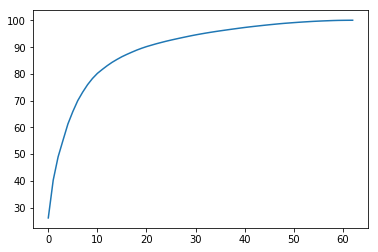

```python
plt.plot(var1)
```

```python
def scree_plot(pca):
    '''
    Creates a scree plot associated with the principal components

    INPUT: pca - the result of instantian of PCA in scikit learn

    OUTPUT:
            None
    '''
    num_components=len(pca.explained_variance_ratio_)
    ind = np.arange(num_components)
    vals = pca.explained_variance_ratio_

    plt.figure(figsize=(10, 6))
    ax = plt.subplot(111)
    cumvals = np.cumsum(vals)
    ax.bar(ind, vals)
    ax.plot(ind, cumvals)
    for i in range(num_components):
        ax.annotate(r"%s%%" % ((str(vals[i]*100)[:4])), (ind[i]+0.2, vals[i]), va="bottom", ha="center", fontsize=12)

    ax.xaxis.set_tick_params(width=0)
    ax.yaxis.set_tick_params(width=2, length=12)

    ax.set_xlabel("Principal Component")
    ax.set_ylabel("Variance Explained (%)")
    plt.title('Explained Variance Per Principal Component')
```

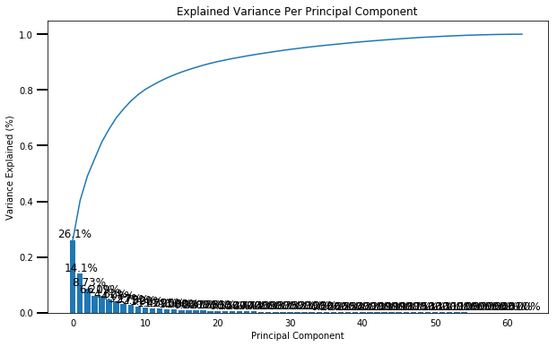

```python
scree_plot(pca)
```

```python
# Investigate the variance accounted for by each principal component.

def pca_results(full_dataset, pca):
    '''
    Create a DataFrame of the PCA results
    Includes dimension feature weights and explained variance Visualizes the PCA results
    '''

    # Dimension indexing
    dimensions = dimensions = ['Dimension {}'.format(i) for i in range(1,len(pca.components_)+1)]

    # PCA components
    components = pd.DataFrame(np.round(pca.components_, 4), columns = full_dataset.keys())
    components.index = dimensions

    # PCA explained variance
    ratios = pca.explained_variance_ratio_.reshape(len(pca.components_), 1)
    variance_ratios = pd.DataFrame(np.round(ratios, 4), columns = ['Explained Variance'])
    variance_ratios.index = dimensions

    # Create a bar plot visualization
    fig, ax = plt.subplots(figsize = (14,8))

    # Plot the feature weights as a function of the components
    components.plot(ax = ax, kind = 'bar');
    ax.set_ylabel("Feature Weights")
    ax.set_xticklabels(dimensions, rotation=0)


    # Display the explained variance ratios
    for i, ev in enumerate(pca.explained_variance_ratio_):
        ax.text(i-0.40, ax.get_ylim()[1] + 0.05, "Explained Variance\n%.4f"%(ev))

    # Return a concatenated DataFrame
    return pd.concat([variance_ratios, components], axis = 1)
```

|  | Explained Variance | ALTERSKATEGORIE_GROB | ANREDE_KZ | FINANZ_MINIMALIST | FINANZ_SPARER | FINANZ_VORSORGER | FINANZ_ANLEGER | FINANZ_UNAUFFAELLIGER | FINANZ_HAUSBAUER | HEALTH_TYP | ... | PLZ8_HHZ | PLZ8_GBZ | ARBEIT | ORTSGR_KLS9 | RELAT_AB | decade | movement | wealth | lifestage | Neighbourhood |
| --- | --- | --- | --- | --- | --- | --- | --- | --- | --- | --- | --- | --- | --- | --- | --- | --- | --- | --- | --- | --- | --- |
| Dimension 1 | 0.2612 | -0.0030 | -0.0025 | 0.0455 | -0.0024 | -0.0070 | 0.0101 | 0.0191 | -0.0844 | -0.0068 | ... | -0.0100 | 0.0510 | -0.0520 | -0.0644 | -0.0403 | 0.0001 | 0.0001 | 0.0002 | -0.0001 | -0.0000 |
| Dimension 2 | 0.1411 | -0.0424 | 0.0034 | -0.1504 | 0.0576 | -0.0413 | 0.0175 | 0.0228 | 0.1179 | 0.0121 | ... | 0.0352 | -0.2471 | 0.1614 | 0.1729 | 0.0987 | -0.0000 | 0.0002 | 0.0003 | -0.0000 | 0.0003 |
| Dimension 3 | 0.0874 | 0.1210 | 0.0253 | 0.0740 | -0.1108 | 0.0968 | -0.0877 | -0.0997 | 0.0324 | -0.0425 | ... | -0.0165 | -0.0923 | 0.0467 | 0.0440 | 0.0249 | 0.0000 | -0.0001 | -0.0002 | 0.0004 | -0.0002 |
| Dimension 4 | 0.0621 | 0.1824 | 0.1312 | 0.0735 | -0.1437 | 0.1230 | -0.0925 | -0.1085 | 0.0472 | -0.0485 | ... | 0.0388 | 0.0905 | -0.0675 | -0.0413 | -0.0364 | -0.0000 | 0.0002 | -0.0002 | 0.0003 | 0.0001 |
| Dimension 5 | 0.0610 | -0.0434 | -0.0541 | 0.0394 | 0.0269 | -0.0210 | 0.0322 | 0.0307 | -0.0888 | 0.0142 | ... | 0.0954 | 0.2433 | -0.2407 | -0.1506 | -0.1438 | 0.0004 | 0.0001 | 0.0002 | 0.0001 | 0.0002 |
| Dimension 6 | 0.0463 | 0.0363 | -0.0579 | 0.1021 | -0.0383 | 0.0165 | -0.0105 | -0.0458 | -0.0592 | -0.0103 | ... | -0.5962 | -0.4407 | 0.0206 | -0.0752 | -0.0004 | -0.0006 | -0.0001 | 0.0001 | 0.0000 | -0.0003 |
| Dimension 7 | 0.0408 | -0.1428 | 0.2940 | -0.2395 | 0.1499 | -0.1263 | 0.2136 | 0.1144 | 0.0575 | 0.0554 | ... | -0.1253 | -0.0436 | -0.0460 | -0.0571 | -0.0308 | -0.0004 | -0.0004 | 0.0000 | 0.0002 | -0.0003 |
| Dimension 8 | 0.0317 | 0.0003 | 0.0198 | 0.0897 | -0.0173 | -0.0030 | -0.0709 | 0.0131 | -0.1078 | -0.0074 | ... | 0.0470 | -0.0993 | 0.0715 | 0.1901 | 0.0703 | 0.0001 | 0.0001 | -0.0002 | -0.0001 | 0.0008 |
| Dimension 9 | 0.0280 | 0.0581 | -0.0408 | 0.0374 | -0.0246 | 0.0377 | 0.0264 | -0.0524 | -0.0104 | -0.0119 | ... | 0.1419 | 0.1127 | 0.2337 | 0.0385 | 0.1062 | 0.0009 | 0.0006 | -0.0004 | -0.0004 | -0.0001 |
| Dimension 10 | 0.0232 | 0.0469 | -0.0210 | -0.0883 | 0.0042 | 0.0318 | 0.0145 | -0.0082 | 0.1113 | -0.0638 | ... | -0.0831 | -0.1465 | -0.5632 | -0.2194 | -0.2929 | 0.0008 | 0.0012 | 0.0010 | 0.0004 | -0.0001 |
| Dimension 11 | 0.0191 | 0.0001 | -0.0002 | -0.0472 | -0.0032 | -0.0005 | -0.0238 | -0.0203 | 0.0957 | -0.0748 | ... | -0.0743 | 0.1202 | 0.3338 | -0.0333 | 0.1605 | 0.0004 | 0.0006 | 0.0016 | -0.0008 | -0.0007 |
| Dimension 12 | 0.0148 | 0.0448 | 0.0461 | -0.1505 | 0.0095 | -0.0011 | 0.0657 | -0.0110 | 0.2924 | -0.5184 | ... | -0.0269 | 0.1205 | 0.2731 | -0.1521 | 0.1197 | -0.0007 | 0.0011 | 0.0018 | -0.0015 | -0.0010 |
| Dimension 13 | 0.0140 | -0.0148 | -0.0563 | 0.0448 | 0.0196 | -0.0329 | 0.0184 | -0.0159 | -0.1298 | 0.5252 | ... | -0.0853 | 0.1637 | 0.1881 | -0.0139 | 0.1142 | 0.0004 | -0.0010 | -0.0005 | 0.0012 | 0.0007 |
| Dimension 14 | 0.0126 | 0.0103 | 0.0457 | 0.0693 | -0.0552 | 0.0640 | -0.1054 | 0.0291 | -0.0578 | -0.4294 | ... | -0.1002 | 0.1106 | -0.1476 | 0.2660 | -0.0584 | -0.0005 | 0.0007 | 0.0018 | -0.0004 | -0.0002 |
| Dimension 15 | 0.0109 | 0.0129 | 0.0102 | 0.0963 | -0.0277 | 0.0061 | 0.0021 | -0.0124 | -0.1044 | 0.0060 | ... | 0.0288 | -0.1049 | -0.0424 | -0.1714 | 0.0894 | -0.0010 | -0.0008 | -0.0018 | 0.0028 | 0.0011 |
| Dimension 16 | 0.0101 | 0.0117 | -0.0551 | -0.2144 | 0.0564 | 0.0455 | -0.0333 | 0.0672 | 0.1886 | 0.2193 | ... | -0.1239 | 0.1353 | -0.1298 | 0.1350 | 0.0057 | -0.0005 | -0.0028 | -0.0038 | 0.0032 | 0.0008 |
| Dimension 17 | 0.0087 | -0.0148 | 0.0254 | 0.2749 | -0.2871 | 0.2516 | -0.2647 | -0.2704 | -0.0395 | 0.1412 | ... | -0.0357 | 0.0431 | 0.0029 | -0.0776 | 0.0658 | 0.0063 | 0.0090 | 0.0214 | -0.0192 | -0.0081 |
| Dimension 18 | 0.0081 | 0.0019 | -0.0001 | 0.0094 | -0.0054 | 0.0055 | -0.0087 | -0.0013 | -0.0156 | -0.0064 | ... | -0.0037 | 0.0051 | -0.0021 | -0.0016 | 0.0155 | -0.1580 | -0.3100 | -0.6680 | 0.6117 | 0.2371 |
| Dimension 19 | 0.0078 | -0.0819 | 0.0311 | -0.0532 | -0.1194 | 0.1199 | -0.0112 | -0.1826 | 0.4928 | 0.2229 | ... | 0.0675 | -0.0833 | 0.0850 | 0.0107 | -0.3598 | -0.0049 | -0.0090 | -0.0239 | 0.0218 | 0.0059 |
| Dimension 20 | 0.0069 | -0.0991 | 0.0424 | -0.0351 | -0.0516 | 0.1433 | -0.0303 | 0.0256 | 0.1958 | 0.0398 | ... | -0.0585 | 0.0747 | -0.0607 | -0.0517 | 0.2207 | 0.0001 | 0.0017 | 0.0056 | -0.0059 | -0.0041 |
| Dimension 21 | 0.0062 | -0.0911 | 0.0301 | -0.0126 | -0.0410 | 0.1528 | -0.0948 | 0.0602 | 0.0001 | -0.0954 | ... | 0.0277 | -0.0129 | -0.1597 | 0.0517 | 0.3614 | 0.0027 | 0.0004 | -0.0009 | -0.0033 | 0.0028 |
| Dimension 22 | 0.0054 | 0.1539 | -0.0352 | -0.1432 | 0.1636 | -0.1095 | 0.0853 | 0.2356 | 0.0201 | 0.2304 | ... | -0.0078 | 0.0406 | -0.0327 | -0.0162 | 0.1272 | 0.0083 | -0.0032 | 0.0005 | -0.0046 | -0.0021 |
| Dimension 23 | 0.0053 | 0.0717 | -0.0077 | -0.0787 | 0.0696 | -0.0272 | 0.0395 | 0.0249 | -0.1069 | 0.0129 | ... | 0.0563 | -0.0106 | -0.0687 | -0.0525 | 0.0813 | -0.0047 | -0.0002 | 0.0002 | -0.0007 | 0.0004 |
| Dimension 24 | 0.0048 | 0.0235 | 0.0318 | 0.1534 | 0.0484 | -0.0927 | 0.1049 | -0.0216 | -0.2661 | -0.0655 | ... | -0.0189 | -0.0355 | 0.1926 | -0.1252 | -0.2425 | 0.0441 | 0.0010 | -0.0100 | -0.0045 | 0.0118 |
| Dimension 25 | 0.0047 | 0.0023 | 0.0014 | 0.0077 | 0.0031 | -0.0037 | 0.0059 | 0.0006 | -0.0126 | 0.0005 | ... | -0.0019 | -0.0036 | 0.0090 | -0.0086 | -0.0077 | -0.9298 | 0.0578 | 0.2463 | 0.1434 | -0.2204 |
| Dimension 26 | 0.0043 | 0.0384 | -0.0081 | -0.0045 | 0.0011 | 0.0194 | -0.0282 | 0.0064 | 0.0359 | 0.0286 | ... | 0.3375 | -0.3392 | -0.0934 | 0.1164 | 0.2078 | 0.0011 | -0.0083 | 0.0010 | 0.0015 | -0.0100 |
| Dimension 27 | 0.0041 | -0.0706 | 0.0029 | -0.0226 | 0.1378 | -0.1865 | 0.1410 | 0.1164 | -0.2844 | -0.1187 | ... | 0.1039 | -0.0238 | 0.0489 | -0.1479 | -0.0511 | 0.0051 | -0.0214 | -0.0021 | 0.0000 | -0.0254 |
| Dimension 28 | 0.0040 | -0.0019 | 0.0002 | 0.0016 | 0.0035 | -0.0063 | 0.0030 | 0.0026 | -0.0020 | 0.0014 | ... | 0.0283 | 0.0129 | -0.0065 | -0.0022 | -0.0049 | -0.1473 | 0.6104 | 0.0073 | -0.0209 | 0.7742 |
| Dimension 29 | 0.0039 | -0.0243 | 0.0016 | 0.0812 | 0.0059 | -0.0229 | -0.0668 | -0.0197 | -0.2584 | -0.0556 | ... | -0.1786 | -0.1943 | 0.1113 | 0.0960 | -0.0731 | -0.0036 | 0.0308 | 0.0019 | 0.0036 | 0.0390 |
| Dimension 30 | 0.0038 | 0.0282 | -0.0017 | -0.1262 | 0.0341 | 0.0152 | 0.1049 | 0.0580 | 0.1632 | 0.0401 | ... | -0.2995 | -0.2237 | 0.0150 | -0.1945 | 0.3015 | -0.0006 | 0.0266 | -0.0020 | 0.0013 | 0.0317 |
| ... | ... | ... | ... | ... | ... | ... | ... | ... | ... | ... | ... | ... | ... | ... | ... | ... | ... | ... | ... | ... | ... |
| Dimension 34 | 0.0030 | 0.0601 | -0.0361 | 0.0430 | 0.0005 | 0.0274 | 0.0134 | 0.0402 | -0.0244 | 0.0688 | ... | 0.0122 | -0.0146 | -0.0258 | 0.0217 | 0.0346 | 0.0090 | 0.0047 | 0.0014 | 0.0060 | -0.0067 |
| Dimension 35 | 0.0029 | 0.0632 | -0.0255 | 0.0575 | -0.0254 | -0.0780 | -0.0525 | -0.0079 | -0.0396 | -0.0036 | ... | -0.1549 | 0.0623 | -0.0956 | 0.0957 | 0.0870 | -0.0034 | -0.0030 | -0.0038 | -0.0074 | -0.0024 |
| Dimension 36 | 0.0027 | 0.0009 | -0.0353 | -0.0619 | 0.0199 | 0.0085 | -0.0515 | 0.0684 | 0.0098 | -0.0699 | ... | -0.2188 | -0.0602 | 0.0677 | 0.3661 | -0.1950 | -0.0034 | -0.0015 | -0.0015 | -0.0090 | 0.0016 |
| Dimension 37 | 0.0026 | -0.0159 | -0.0778 | -0.0754 | -0.0059 | -0.0987 | -0.1253 | 0.1755 | -0.0085 | -0.0266 | ... | 0.0943 | -0.0846 | 0.0474 | -0.0687 | -0.0483 | -0.0030 | 0.0005 | -0.0023 | -0.0005 | -0.0030 |
| Dimension 38 | 0.0026 | 0.0092 | 0.0305 | -0.0251 | -0.0639 | 0.0208 | -0.1110 | 0.0905 | 0.0816 | 0.0615 | ... | 0.1113 | -0.2039 | 0.0895 | 0.0101 | -0.1153 | 0.0018 | -0.0027 | 0.0005 | -0.0015 | 0.0003 |
| Dimension 39 | 0.0025 | 0.0166 | 0.0251 | -0.0192 | -0.0006 | -0.0109 | 0.0046 | -0.0176 | -0.0586 | 0.0131 | ... | -0.3038 | 0.3881 | -0.0181 | -0.0835 | 0.0362 | -0.0010 | 0.0010 | -0.0029 | -0.0009 | 0.0005 |
| Dimension 40 | 0.0025 | -0.0146 | -0.0356 | -0.0068 | -0.0237 | 0.0092 | -0.0774 | 0.0647 | 0.0691 | 0.0058 | ... | -0.2952 | 0.2490 | 0.0515 | 0.0476 | -0.0580 | -0.0018 | -0.0062 | 0.0037 | -0.0016 | 0.0032 |
| Dimension 41 | 0.0024 | -0.0435 | 0.0083 | 0.0115 | -0.0360 | 0.0285 | 0.0498 | -0.0346 | 0.0502 | -0.0611 | ... | 0.0570 | 0.0259 | -0.0494 | -0.2330 | 0.1357 | -0.0040 | -0.0059 | -0.0013 | -0.0066 | 0.0037 |
| Dimension 42 | 0.0022 | 0.0350 | -0.0430 | 0.0121 | 0.0237 | -0.1130 | 0.0347 | -0.1094 | 0.0064 | -0.0331 | ... | 0.0313 | -0.0681 | -0.1984 | 0.1580 | 0.2362 | -0.0013 | -0.0027 | -0.0026 | -0.0050 | 0.0012 |
| Dimension 43 | 0.0021 | -0.1486 | 0.1379 | 0.0257 | -0.0559 | 0.0336 | -0.0417 | 0.0850 | -0.1090 | 0.1126 | ... | -0.0324 | -0.0273 | 0.0249 | 0.1266 | -0.0414 | 0.0015 | -0.0088 | 0.0096 | 0.0044 | 0.0062 |
| Dimension 44 | 0.0020 | 0.0009 | 0.0020 | 0.0740 | 0.0232 | -0.1132 | 0.0896 | -0.1205 | 0.0015 | -0.0054 | ... | -0.0422 | 0.0491 | -0.1581 | 0.1610 | 0.1454 | -0.0031 | 0.0013 | -0.0061 | -0.0046 | -0.0036 |
| Dimension 45 | 0.0020 | 0.0393 | -0.0670 | -0.0623 | -0.0246 | 0.0810 | -0.0999 | 0.1514 | 0.0660 | -0.0382 | ... | 0.0230 | -0.0382 | 0.1595 | -0.2127 | -0.1297 | 0.0030 | -0.0049 | 0.0064 | 0.0041 | 0.0052 |
| Dimension 46 | 0.0019 | 0.0011 | -0.0027 | 0.0027 | 0.0014 | -0.0038 | 0.0031 | -0.0009 | 0.0035 | -0.0016 | ... | -0.0005 | 0.0020 | -0.0053 | 0.0048 | 0.0044 | 0.0793 | -0.5383 | 0.6520 | 0.2889 | 0.4409 |
| Dimension 47 | 0.0018 | 0.0951 | 0.0215 | -0.0030 | -0.0149 | 0.0334 | -0.0800 | 0.1022 | -0.0042 | 0.0155 | ... | 0.0421 | -0.0594 | 0.1130 | -0.1180 | -0.1104 | 0.0013 | -0.0084 | 0.0129 | 0.0059 | 0.0086 |
| Dimension 48 | 0.0018 | 0.0531 | 0.0025 | 0.0435 | -0.0030 | -0.1276 | 0.0646 | -0.1362 | 0.0217 | 0.0044 | ... | -0.0374 | 0.0680 | -0.1323 | 0.0435 | 0.1340 | 0.0021 | -0.0037 | 0.0012 | 0.0016 | 0.0037 |
| Dimension 49 | 0.0016 | 0.0038 | -0.0242 | -0.3329 | 0.1312 | 0.3697 | 0.3933 | -0.5346 | -0.2184 | -0.0282 | ... | 0.0214 | -0.0311 | 0.0547 | 0.0850 | -0.0526 | -0.0000 | -0.0022 | 0.0037 | 0.0012 | 0.0027 |
| Dimension 50 | 0.0014 | 0.0902 | -0.0535 | -0.1913 | -0.0350 | 0.0009 | -0.1201 | 0.0066 | -0.0582 | 0.0319 | ... | 0.0179 | 0.0020 | 0.0144 | -0.0164 | -0.0201 | -0.0005 | 0.0019 | 0.0005 | 0.0007 | 0.0005 |
| Dimension 51 | 0.0014 | 0.0212 | 0.0158 | -0.1695 | -0.0083 | 0.0565 | -0.1177 | -0.0505 | -0.0898 | -0.0148 | ... | 0.0050 | -0.0137 | 0.0524 | -0.1074 | -0.0651 | 0.0003 | 0.0018 | -0.0024 | -0.0017 | -0.0011 |
| Dimension 52 | 0.0013 | -0.0566 | -0.0012 | 0.0711 | -0.0186 | 0.0072 | -0.0532 | 0.1702 | 0.0126 | -0.0111 | ... | 0.0235 | 0.0291 | 0.0159 | 0.1383 | -0.0134 | -0.0022 | 0.0013 | -0.0036 | -0.0031 | -0.0025 |
| Dimension 53 | 0.0012 | -0.0300 | 0.1257 | 0.2034 | 0.0140 | -0.1269 | -0.0569 | 0.1188 | 0.1145 | -0.0233 | ... | 0.0036 | -0.0144 | 0.0196 | -0.0177 | -0.0187 | 0.0001 | -0.0006 | 0.0004 | 0.0010 | 0.0002 |
| Dimension 54 | 0.0011 | -0.0377 | 0.0445 | -0.1343 | 0.0020 | 0.1416 | -0.0275 | 0.0008 | -0.0589 | -0.0030 | ... | -0.0159 | 0.0536 | 0.0236 | -0.0053 | -0.0424 | -0.0010 | -0.0001 | 0.0010 | 0.0005 | 0.0010 |
| Dimension 55 | 0.0011 | 0.0642 | -0.0299 | 0.5190 | 0.0363 | 0.2350 | 0.6268 | 0.2006 | 0.2085 | 0.0078 | ... | -0.0010 | -0.0057 | 0.0293 | 0.0709 | -0.0452 | 0.0009 | 0.0015 | -0.0022 | -0.0003 | -0.0013 |
| Dimension 56 | 0.0009 | -0.6043 | 0.1945 | -0.1200 | -0.2512 | 0.1649 | 0.0768 | 0.1388 | -0.1221 | -0.0126 | ... | 0.0090 | -0.0058 | -0.0264 | 0.0360 | 0.0263 | 0.0003 | 0.0006 | 0.0017 | -0.0001 | 0.0019 |
| Dimension 57 | 0.0008 | 0.3381 | -0.1479 | 0.0023 | 0.1800 | -0.0639 | -0.0690 | -0.1548 | 0.0318 | 0.0052 | ... | 0.0024 | -0.0132 | 0.0188 | -0.0606 | -0.0236 | 0.0005 | -0.0002 | 0.0008 | -0.0003 | 0.0005 |
| Dimension 58 | 0.0007 | -0.3396 | -0.0893 | 0.1170 | 0.1498 | -0.0774 | -0.0171 | -0.1208 | 0.0713 | -0.0251 | ... | -0.0358 | -0.0110 | 0.0234 | -0.2233 | -0.0317 | -0.0003 | -0.0007 | 0.0003 | -0.0000 | -0.0004 |
| Dimension 59 | 0.0007 | 0.3205 | -0.1161 | -0.2088 | -0.3919 | 0.3628 | 0.1562 | 0.4047 | -0.1980 | 0.0039 | ... | -0.0118 | 0.0036 | -0.0247 | -0.0619 | 0.0183 | -0.0003 | 0.0005 | -0.0004 | -0.0002 | 0.0004 |
| Dimension 60 | 0.0005 | 0.0935 | 0.0894 | -0.1123 | -0.6689 | -0.5399 | 0.2803 | -0.1732 | 0.0287 | 0.0180 | ... | 0.0019 | -0.0060 | 0.0269 | 0.0033 | -0.0239 | -0.0001 | 0.0002 | 0.0005 | 0.0007 | 0.0001 |
| Dimension 61 | 0.0003 | -0.2815 | -0.8456 | -0.0351 | -0.1364 | -0.0581 | 0.0542 | 0.0046 | 0.0276 | -0.0616 | ... | 0.0053 | -0.0014 | -0.0010 | 0.0208 | 0.0013 | 0.0000 | 0.0004 | 0.0000 | -0.0000 | -0.0005 |
| Dimension 62 | 0.0002 | 0.0010 | 0.0009 | -0.0005 | 0.0004 | 0.0004 | -0.0001 | -0.0000 | -0.0005 | 0.0004 | ... | 0.0001 | 0.0000 | -0.0002 | -0.0000 | 0.0001 | 0.0000 | -0.0004 | 0.0002 | 0.0000 | -0.0000 |
| Dimension 63 | 0.0001 | -0.0016 | 0.0042 | 0.0010 | 0.0012 | 0.0007 | -0.0016 | 0.0014 | -0.0013 | 0.0001 | ... | 0.0000 | 0.0002 | -0.0001 | -0.0007 | -0.0002 | -0.0002 | 0.0000 | -0.0000 | 0.0000 | 0.0000 |

63 rows × 64 columns

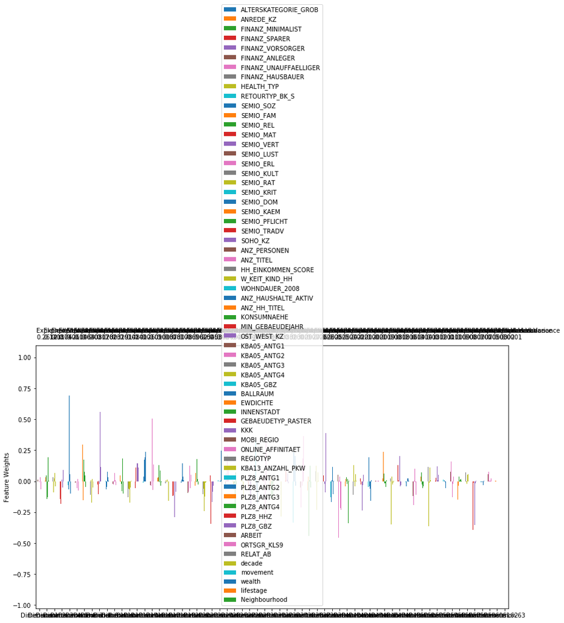

```python
pca_results(azdias_few_missing_values, pca)
```

```python
# Re-apply PCA to the data while selecting for number of components to retain.
#pca_reduced, azdias_data_pca_reduced= do_pca(15, scaled_azdias_data)
pca_reduced = PCA(n_components=33).fit(scaled_azdias_data)
azdias_data_pca_reduced = pca_reduced.transform(scaled_azdias_data)
```

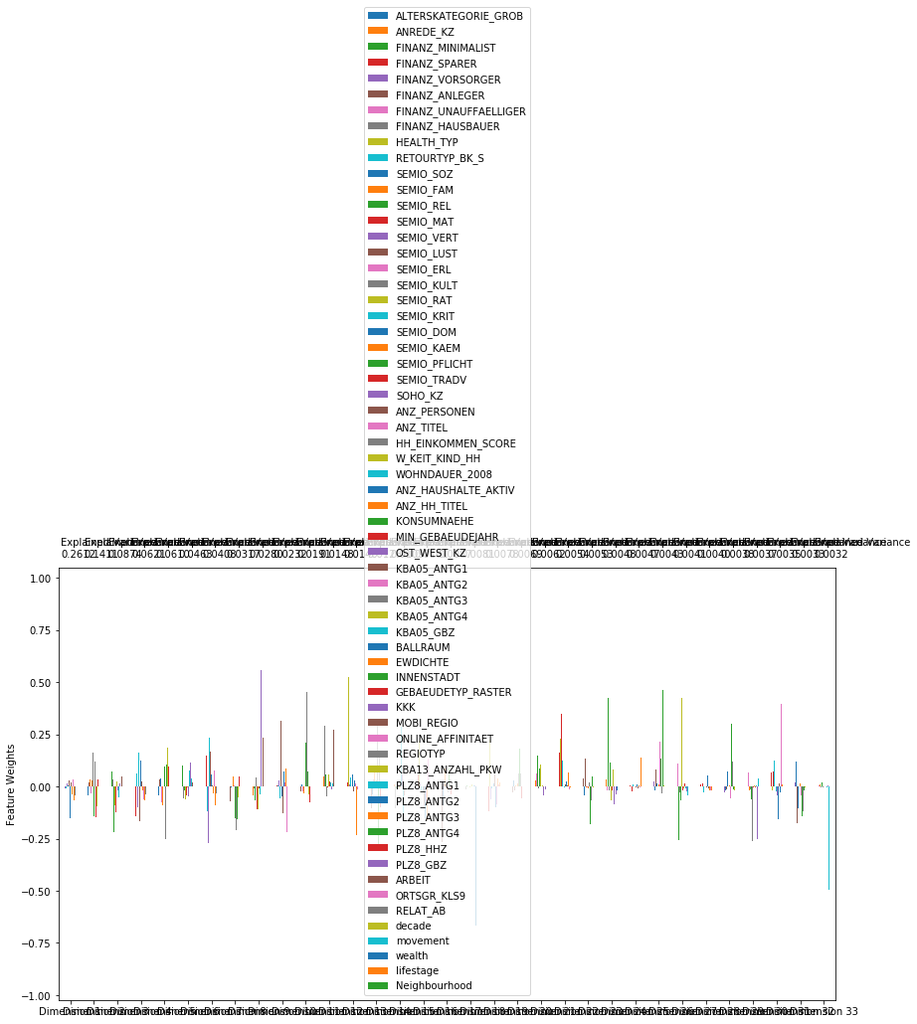

```python
pca_comp_df = pca_results(azdias_few_missing_values, pca_reduced)
#pca_comp_df
```

### Discussion 2.2: Perform Dimensionality Reduction

I am retaining 33 components, which will explain 95% variability in the data, for the clustering process.

### Step 2.3: Interpret Principal Components

Now that we have our transformed principal components, it's a nice idea to check out the weight of each variable on the first few components to see if they can be interpreted in some fashion.

As a reminder, each principal component is a unit vector that points in the direction of highest variance (after accounting for the variance captured by earlier principal components). The further a weight is from zero, the more the principal component is in the direction of the corresponding feature. If two features have large weights of the same sign (both positive or both negative), then increases in one tend expect to be associated with increases in the other. To contrast, features with different signs can be expected to show a negative correlation: increases in one variable should result in a decrease in the other.

- To investigate the features, you should map each weight to their corresponding feature name, then sort the features according to weight. The most interesting features for each principal component, then, will be those at the beginning and end of the sorted list. Use the data dictionary document to help you understand these most prominent features, their relationships, and what a positive or negative value on the principal component might indicate.
- You should investigate and interpret feature associations from the first three principal components in this substep. To help facilitate this, you should write a function that you can call at any time to print the sorted list of feature weights, for the *i*-th principal component. This might come in handy in the next step of the project, when you interpret the tendencies of the discovered clusters.

```python
def sort_features(pca_number):
    df = pca_comp_df.loc['Dimension {}'.format(pca_number)][1:].sort_values(ascending=False)
    return df.to_frame()
```

```python
# Map weights for the first principal component to corresponding feature names
# and then print the linked values, sorted by weight.
# HINT: Try defining a function here or in a new cell that you can reuse in the
# other cells.
sort_features(1)
```

|  | Dimension 1 |
| --- | --- |
| MIN_GEBAEUDEJAHR | 0.9545 |
| KONSUMNAEHE | 0.0604 |
| MOBI_REGIO | 0.0514 |
| PLZ8_GBZ | 0.0510 |
| GEBAEUDETYP_RASTER | 0.0457 |
| FINANZ_MINIMALIST | 0.0455 |
| INNENSTADT | 0.0431 |
| KBA05_GBZ | 0.0427 |
| ONLINE_AFFINITAET | 0.0323 |
| BALLRAUM | 0.0294 |
| PLZ8_ANTG1 | 0.0289 |
| ANZ_PERSONEN | 0.0285 |
| KBA13_ANZAHL_PKW | 0.0223 |
| FINANZ_UNAUFFAELLIGER | 0.0191 |
| KBA05_ANTG1 | 0.0184 |
| SEMIO_VERT | 0.0150 |
| SEMIO_MAT | 0.0124 |
| FINANZ_ANLEGER | 0.0101 |
| SEMIO_TRADV | 0.0069 |
| KKK | 0.0054 |
| SEMIO_KRIT | 0.0048 |
| SEMIO_RAT | 0.0046 |
| SEMIO_FAM | 0.0006 |
| wealth | 0.0002 |
| decade | 0.0001 |
| movement | 0.0001 |
| SOHO_KZ | 0.0001 |
| Neighbourhood | -0.0000 |
| ANZ_TITEL | -0.0001 |
| lifestage | -0.0001 |
| ... | ... |
| OST_WEST_KZ | -0.0034 |
| REGIOTYP | -0.0035 |
| SEMIO_ERL | -0.0043 |
| SEMIO_PFLICHT | -0.0045 |
| SEMIO_REL | -0.0053 |
| SEMIO_KULT | -0.0064 |
| HEALTH_TYP | -0.0068 |
| FINANZ_VORSORGER | -0.0070 |
| KBA05_ANTG2 | -0.0079 |
| ANZ_HH_TITEL | -0.0083 |
| RETOURTYP_BK_S | -0.0088 |
| PLZ8_HHZ | -0.0100 |
| SEMIO_KAEM | -0.0107 |
| SEMIO_SOZ | -0.0120 |
| SEMIO_DOM | -0.0132 |
| SEMIO_LUST | -0.0186 |
| PLZ8_ANTG2 | -0.0247 |
| W_KEIT_KIND_HH | -0.0276 |
| EWDICHTE | -0.0372 |
| RELAT_AB | -0.0403 |
| KBA05_ANTG4 | -0.0456 |
| PLZ8_ANTG4 | -0.0459 |
| ARBEIT | -0.0520 |
| KBA05_ANTG3 | -0.0624 |
| ORTSGR_KLS9 | -0.0644 |
| PLZ8_ANTG3 | -0.0666 |
| WOHNDAUER_2008 | -0.0709 |
| HH_EINKOMMEN_SCORE | -0.0794 |
| FINANZ_HAUSBAUER | -0.0844 |
| ANZ_HAUSHALTE_AKTIV | -0.1526 |

63 rows × 1 columns

```python
# Map weights for the second principal component to corresponding feature names
# and then print the linked values, sorted by weight.

sort_features(2)
```

|  | Dimension 2 |
| --- | --- |
| ANZ_HAUSHALTE_AKTIV | 0.5388 |
| PLZ8_ANTG3 | 0.2505 |
| MIN_GEBAEUDEJAHR | 0.2361 |
| PLZ8_ANTG4 | 0.1948 |
| ORTSGR_KLS9 | 0.1729 |
| ARBEIT | 0.1614 |
| HH_EINKOMMEN_SCORE | 0.1602 |
| KBA05_ANTG4 | 0.1359 |
| KBA05_ANTG3 | 0.1190 |
| FINANZ_HAUSBAUER | 0.1179 |
| RELAT_AB | 0.0987 |
| EWDICHTE | 0.0926 |
| SEMIO_REL | 0.0757 |
| PLZ8_ANTG2 | 0.0661 |
| FINANZ_SPARER | 0.0576 |
| SEMIO_PFLICHT | 0.0478 |
| SEMIO_MAT | 0.0441 |
| REGIOTYP | 0.0424 |
| SEMIO_RAT | 0.0359 |
| KKK | 0.0357 |
| PLZ8_HHZ | 0.0352 |
| W_KEIT_KIND_HH | 0.0348 |
| SEMIO_TRADV | 0.0331 |
| SEMIO_FAM | 0.0318 |
| ANZ_HH_TITEL | 0.0293 |
| SEMIO_KULT | 0.0284 |
| SEMIO_KAEM | 0.0276 |
| FINANZ_UNAUFFAELLIGER | 0.0228 |
| FINANZ_ANLEGER | 0.0175 |
| SEMIO_SOZ | 0.0155 |
| ... | ... |
| ANREDE_KZ | 0.0034 |
| RETOURTYP_BK_S | 0.0029 |
| Neighbourhood | 0.0003 |
| wealth | 0.0003 |
| movement | 0.0002 |
| lifestage | -0.0000 |
| decade | -0.0000 |
| SOHO_KZ | -0.0002 |
| ANZ_TITEL | -0.0003 |
| SEMIO_VERT | -0.0148 |
| KBA05_ANTG2 | -0.0224 |
| ONLINE_AFFINITAET | -0.0280 |
| SEMIO_LUST | -0.0316 |
| SEMIO_ERL | -0.0322 |
| OST_WEST_KZ | -0.0347 |
| FINANZ_VORSORGER | -0.0413 |
| ALTERSKATEGORIE_GROB | -0.0424 |
| BALLRAUM | -0.0795 |
| KBA13_ANZAHL_PKW | -0.0936 |
| KBA05_ANTG1 | -0.1223 |
| PLZ8_ANTG1 | -0.1261 |
| INNENSTADT | -0.1274 |
| KONSUMNAEHE | -0.1423 |
| ANZ_PERSONEN | -0.1426 |
| GEBAEUDETYP_RASTER | -0.1455 |
| FINANZ_MINIMALIST | -0.1504 |
| KBA05_GBZ | -0.1736 |
| MOBI_REGIO | -0.2048 |
| PLZ8_GBZ | -0.2471 |
| WOHNDAUER_2008 | -0.2972 |

63 rows × 1 columns

```python
# Map weights for the third principal component to corresponding feature names
# and then print the linked values, sorted by weight.

sort_features(3)
```

|  | Dimension 3 |
| --- | --- |
| WOHNDAUER_2008 | 0.7954 |
| ANZ_HAUSHALTE_AKTIV | 0.2993 |
| MIN_GEBAEUDEJAHR | 0.1466 |
| ALTERSKATEGORIE_GROB | 0.1210 |
| SEMIO_ERL | 0.1188 |
| FINANZ_VORSORGER | 0.0968 |
| SEMIO_LUST | 0.0870 |
| FINANZ_MINIMALIST | 0.0740 |
| RETOURTYP_BK_S | 0.0734 |
| KBA05_ANTG4 | 0.0669 |
| ANZ_PERSONEN | 0.0598 |
| PLZ8_ANTG4 | 0.0539 |
| PLZ8_ANTG3 | 0.0481 |
| ARBEIT | 0.0467 |
| SEMIO_KAEM | 0.0444 |
| ORTSGR_KLS9 | 0.0440 |
| SEMIO_KRIT | 0.0381 |
| FINANZ_HAUSBAUER | 0.0324 |
| ANREDE_KZ | 0.0253 |
| RELAT_AB | 0.0249 |
| W_KEIT_KIND_HH | 0.0238 |
| EWDICHTE | 0.0216 |
| ANZ_HH_TITEL | 0.0215 |
| SEMIO_DOM | 0.0194 |
| KKK | 0.0132 |
| REGIOTYP | 0.0114 |
| PLZ8_ANTG2 | 0.0008 |
| ANZ_TITEL | 0.0008 |
| lifestage | 0.0004 |
| SOHO_KZ | 0.0001 |
| ... | ... |
| Neighbourhood | -0.0002 |
| KBA05_ANTG3 | -0.0067 |
| HH_EINKOMMEN_SCORE | -0.0076 |
| SEMIO_VERT | -0.0086 |
| PLZ8_HHZ | -0.0165 |
| KONSUMNAEHE | -0.0183 |
| OST_WEST_KZ | -0.0197 |
| BALLRAUM | -0.0216 |
| KBA05_ANTG1 | -0.0248 |
| PLZ8_ANTG1 | -0.0282 |
| GEBAEUDETYP_RASTER | -0.0312 |
| INNENSTADT | -0.0327 |
| SEMIO_SOZ | -0.0330 |
| KBA13_ANZAHL_PKW | -0.0402 |
| KBA05_ANTG2 | -0.0423 |
| HEALTH_TYP | -0.0425 |
| MOBI_REGIO | -0.0460 |
| KBA05_GBZ | -0.0544 |
| SEMIO_FAM | -0.0680 |
| ONLINE_AFFINITAET | -0.0835 |
| FINANZ_ANLEGER | -0.0877 |
| SEMIO_MAT | -0.0881 |
| SEMIO_RAT | -0.0898 |
| PLZ8_GBZ | -0.0923 |
| FINANZ_UNAUFFAELLIGER | -0.0997 |
| FINANZ_SPARER | -0.1108 |
| SEMIO_KULT | -0.1159 |
| SEMIO_TRADV | -0.1216 |
| SEMIO_PFLICHT | -0.1304 |
| SEMIO_REL | -0.2166 |

63 rows × 1 columns

### Discussion 2.3: Interpret Principal Components

From the first principal component,it can be observed that 'MIN_GEBAEUDEJAHR' is the most predominant feature.  
From the second principal component, it can be observed that 'ANZ_HAUSHALTE_AKTIV' is the most predominat feature. An increase in 'PLZ8_ANTG3' feature value will cause a decrease in 'WOHNDAUER_2008' feature value.  
From the third principal component, it can be observed that 'WOHNDAUER_2008' is the most predominant feature. An increase in 'ANZ_HAUSHALTE_AKTIV' feature value will cause a decrease in 'SEMIO_REL' feature value.

## Step 3: Clustering

### Step 3.1: Apply Clustering to General Population

You've assessed and cleaned the demographics data, then scaled and transformed them. Now, it's time to see how the data clusters in the principal components space. In this substep, you will apply k-means clustering to the dataset and use the average within-cluster distances from each point to their assigned cluster's centroid to decide on a number of clusters to keep.

- Use sklearn's KMeans class to perform k-means clustering on the PCA-transformed data.
- Then, compute the average difference from each point to its assigned cluster's center. **Hint**: The KMeans object's `.score()` method might be useful here, but note that in sklearn, scores tend to be defined so that larger is better. Try applying it to a small, toy dataset, or use an internet search to help your understanding.
- Perform the above two steps for a number of different cluster counts. You can then see how the average distance decreases with an increasing number of clusters. However, each additional cluster provides a smaller net benefit. Use this fact to select a final number of clusters in which to group the data. **Warning**: because of the large size of the dataset, it can take a long time for the algorithm to resolve. The more clusters to fit, the longer the algorithm will take. You should test for cluster counts through at least 10 clusters to get the full picture, but you shouldn't need to test for a number of clusters above about 30.
- Once you've selected a final number of clusters to use, re-fit a KMeans instance to perform the clustering operation. Make sure that you also obtain the cluster assignments for the general demographics data, since you'll be using them in the final Step 3.3.

```python
num_clusters = np.arange(10,20)
results = {}
for size in num_clusters:
    model = KMeans(n_clusters = size).fit(azdias_data_pca_reduced)
    #predictions = model.predict(azdias_data_pca_reduced)
    inertia_score=model.inertia_
    results[size] = inertia_score
    print("For n_clusters =", size,"The sum of squared distance is :", inertia_score)
```

```
For n_clusters = 10 The sum of squared distance is : 16630799.4173
For n_clusters = 11 The sum of squared distance is : 16235241.463
For n_clusters = 12 The sum of squared distance is : 15893164.7883
For n_clusters = 13 The sum of squared distance is : 15583197.959
For n_clusters = 14 The sum of squared distance is : 15348962.2551
For n_clusters = 15 The sum of squared distance is : 15104674.4668
For n_clusters = 16 The sum of squared distance is : 14924081.7003
For n_clusters = 17 The sum of squared distance is : 14710820.2591
For n_clusters = 18 The sum of squared distance is : 14572425.0713
For n_clusters = 19 The sum of squared distance is : 14412866.3383
```

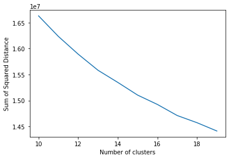

```python
# Investigate the change in within-cluster distance across number of clusters.
# HINT: Use matplotlib's plot function to visualize this relationship.
lists = sorted(results.items()) # sorted by key, return a list of tuples

x, y = zip(*lists) # unpack a list of pairs into two tuples

plt.plot(x, y)
plt.xlabel("Number of clusters")
plt.ylabel("Sum of Squared Distance")
plt.show()
```

```python
# Re-fit the k-means model with the selected number of clusters and obtain
# cluster predictions for the general population demographics data.

# TODO: Create an instance of KMeans to find two clusters
kmeans_10 = KMeans(n_clusters=10)

# TODO: use fit_predict to cluster the dataset
predictions = kmeans_10.fit_predict(azdias_data_pca_reduced)
```

```python
demo_pred = np.unique(predictions, return_counts=True)
demo_pred
```

```
(array([0, 1, 2, 3, 4, 5, 6, 7, 8, 9], dtype=int32),
 array([ 25122, 110556,  51623, 138213,  92379,  47557,   4308, 129748,
         90928, 106992]))
```

```python
demo_dict={}
```

```python
for i in range(0,len(demo_pred[0])):
    demo_dict[demo_pred[0][i]] = demo_pred[1][i]
```

### Discussion 3.1: Apply Clustering to General Population

I have decided to use 10 clusters in my final model as the sum of squared distance is higher for 10 clusters compared to other cluster numbers.

### Step 3.2: Apply All Steps to the Customer Data

Now that you have clusters and cluster centers for the general population, it's time to see how the customer data maps on to those clusters. Take care to not confuse this for re-fitting all of the models to the customer data. Instead, you're going to use the fits from the general population to clean, transform, and cluster the customer data. In the last step of the project, you will interpret how the general population fits apply to the customer data.

- Don't forget when loading in the customers data, that it is semicolon (`;`) delimited.
- Apply the same feature wrangling, selection, and engineering steps to the customer demographics using the `clean_data()` function you created earlier. (You can assume that the customer demographics data has similar meaning behind missing data patterns as the general demographics data.)
- Use the sklearn objects from the general demographics data, and apply their transformations to the customers data. That is, you should not be using a `.fit()` or `.fit_transform()` method to re-fit the old objects, nor should you be creating new sklearn objects! Carry the data through the feature scaling, PCA, and clustering steps, obtaining cluster assignments for all of the data in the customer demographics data.

```python
# Load in the customer demographics data.
customers_data = pd.read_csv('Udacity_CUSTOMERS_Subset.csv', sep=';')
```

```python
# Apply preprocessing, feature transformation, and clustering from the general
# demographics onto the customer data, obtaining cluster predictions for the
# customer demographics data.

customer_data_cleaned = clean_data(customers_data)
```

```python
#Impute missing values
customer_data_imputed = imp.transform(customer_data_cleaned)
customer_data_scaled = scaler.transform(customer_data_imputed)
customer_data_pca_reduced = pca_reduced.transform(customer_data_scaled)
```

```python
customer_predictions=kmeans_10.predict(customer_data_pca_reduced)
```

```python
cust_pred = np.unique(customer_predictions, return_counts=True)
cust_pred
```

```
(array([0, 1, 2, 3, 4, 5, 6, 7, 8, 9], dtype=int32),
 array([ 1037,  4606,  7625, 22016,  4521,  4321,   523, 49165,  1983, 37630]))
```

```python
cust_dict={}
```

```python
for i in range(0,len(cust_pred[0])):
    cust_dict[cust_pred[0][i]] = cust_pred[1][i]
```

```python
centers = kmeans_10.cluster_centers_
```

### Step 3.3: Compare Customer Data to Demographics Data

At this point, you have clustered data based on demographics of the general population of Germany, and seen how the customer data for a mail-order sales company maps onto those demographic clusters. In this final substep, you will compare the two cluster distributions to see where the strongest customer base for the company is.

Consider the proportion of persons in each cluster for the general population, and the proportions for the customers. If we think the company's customer base to be universal, then the cluster assignment proportions should be fairly similar between the two. If there are only particular segments of the population that are interested in the company's products, then we should see a mismatch from one to the other. If there is a higher proportion of persons in a cluster for the customer data compared to the general population (e.g. 5% of persons are assigned to a cluster for the general population, but 15% of the customer data is closest to that cluster's centroid) then that suggests the people in that cluster to be a target audience for the company. On the other hand, the proportion of the data in a cluster being larger in the general population than the customer data (e.g. only 2% of customers closest to a population centroid that captures 6% of the data) suggests that group of persons to be outside of the target demographics.

Take a look at the following points in this step:

- Compute the proportion of data points in each cluster for the general population and the customer data. Visualizations will be useful here: both for the individual dataset proportions, but also to visualize the ratios in cluster representation between groups. Seaborn's [`countplot()`](https://seaborn.pydata.org/generated/seaborn.countplot.html) or [`barplot()`](https://seaborn.pydata.org/generated/seaborn.barplot.html) function could be handy.
  - Recall the analysis you performed in step 1.1.3 of the project, where you separated out certain data points from the dataset if they had more than a specified threshold of missing values. If you found that this group was qualitatively different from the main bulk of the data, you should treat this as an additional data cluster in this analysis. Make sure that you account for the number of data points in this subset, for both the general population and customer datasets, when making your computations!
- Which cluster or clusters are overrepresented in the customer dataset compared to the general population? Select at least one such cluster and infer what kind of people might be represented by that cluster. Use the principal component interpretations from step 2.3 or look at additional components to help you make this inference. Alternatively, you can use the `.inverse_transform()` method of the PCA and StandardScaler objects to transform centroids back to the original data space and interpret the retrieved values directly.
- Perform a similar investigation for the underrepresented clusters. Which cluster or clusters are underrepresented in the customer dataset compared to the general population, and what kinds of people are typified by these clusters?

```python
customers_data.shape[0]-customer_data_cleaned.shape[0]
```

```
58225
```

```python
demo_dict['outlier_data'] = azdias_many_missing_values.shape[0]
cust_dict['outlier_data']= customers_data.shape[0]-customer_data_cleaned.shape[0]
```

```python
demo_total = sum(demo_dict.values(), 0.0)
demo_prop = {k: v / demo_total for k, v in demo_dict.items()}
```

```python
cust_total = sum(cust_dict.values(), 0.0)
cust_prop = {k: v / cust_total for k, v in cust_dict.items()}
```

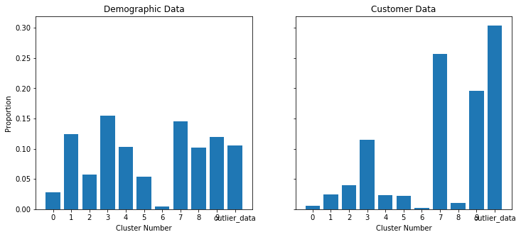

```python
# Compare the proportion of data in each cluster for the customer data to the
# proportion of data in each cluster for the general population.
#plt.bar(demo_prop.keys(), demo_prop.values())
fig, (ax1, ax2) =plt.subplots(1,2,figsize=(12, 5),sharey=True)
ax1.bar(demo_prop.keys(), demo_prop.values())
ax1.set_title("Demographic Data")
ax1.set_xlabel('Cluster Number')
ax1.set_ylabel('Proportion')
ax2.bar(cust_prop.keys(), cust_prop.values())
ax2.set_title("Customer Data")
ax2.set_xlabel('Cluster Number')
plt.show()
```

```python
proportion_comparison=d3 = {key: demo_prop[key] - cust_prop.get(key, 0) for key in demo_prop.keys()}
proportion_comparison
```

```
{0: 0.022777445655708134,
 1: 0.10001689581010602,
 2: 0.018138251233303537,
 3: 0.040207868648524464,
 4: 0.080064793453539243,
 5: 0.030815551018136732,
 6: 0.0021049134018887245,
 7: -0.1109481330453537,
 8: 0.091679442475384079,
 9: -0.076294428365143524,
 'outlier_data': -0.19856260028609379}
```

By comparing the 2 plots, it can be seen that the customers in cluster number 7 are likely to be the target audience for the mail order company while the customers in cluster number 1 are the group of persons outside the target audience.

```python
# # TODO: Inverse transform the centers
# pca_inverse = pca_reduced.inverse_transform(centers)

# # TODO: Exponentiate the centers
# scaler_inverse = scaler.inverse_transform(pca_inverse)

# # Display the true centers
# segments = ['Cluster {}'.format(i) for i in range(0,len(centers))]
# true_centers = pd.DataFrame(np.round(scaler_inverse), columns = azdias_few_missing_values.keys())
# true_centers.index = segments
# display(true_centers)
```

```python
def plot_scaled_comparison(df_sample, kmeans, cluster):
    X = pd.DataFrame.from_dict(dict(zip(df_sample.columns,
    pca_reduced.inverse_transform(kmeans.cluster_centers_[cluster]))), orient='index').rename(
    columns={0: 'feature_values'}).sort_values('feature_values', ascending=False)
    X['feature_values_abs'] = abs(X['feature_values'])
    pd.concat((X['feature_values'][:10], X['feature_values'][-10:]), axis=0).plot(kind='barh');
```

People in cluster number 7 of the customer data is overrepresented.

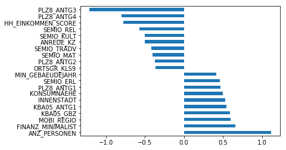

```python
# What kinds of people are part of a cluster that is overrepresented in the
# customer data compared to the general population?

plot_scaled_comparison(customer_data_cleaned,kmeans_10,7)
```

People in cluster number 1 of the customer data is underrepresented.

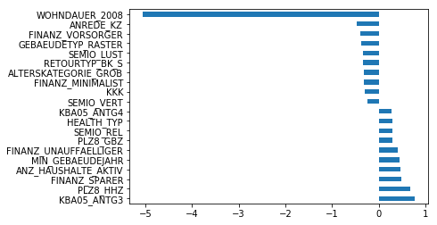

```python
# What kinds of people are part of a cluster that is underrepresented in the
# customer data compared to the general population?
plot_scaled_comparison(customer_data_cleaned,kmeans_10,1)
```

### Discussion 3.3: Compare Customer Data to Demographics Data

> Congratulations on making it this far in the project! Before you finish, make sure to check through the entire notebook from top to bottom to make sure that your analysis follows a logical flow and all of your findings are documented in **Discussion** cells. Once you've checked over all of your work, you should export the notebook as an HTML document to submit for evaluation. You can do this from the menu, navigating to **File -> Download as -> HTML (.html)**. You will submit both that document and this notebook for your project submission.